# Overview

Dataset info

| Number of variables | 194 |
| --- | --- |
| Number of observations | 1584 |
| Total Missing (%) | 0.0% |
| Total size in memory | 2.3 MiB |
| Average record size in memory | 1.5 KiB |

Variables types

| Numeric | 130 |
| --- | --- |
| Categorical | 0 |
| Date | 0 |
| Text (Unique) | 0 |
| Rejected | 64 |

Warnings

- `id` is highly correlated with `index` (ρ = 0.91382) Rejected
- `margin1` has 326 / 20.6% zeros
- `margin10` has 154 / 9.7% zeros
- `margin11` has 240 / 15.2% zeros
- `margin12` has 244 / 15.4% zeros
- `margin13` has 143 / 9.0% zeros
- `margin14` has 492 / 31.1% zeros
- `margin15` has 219 / 13.8% zeros
- `margin16` has 1560 / 98.5% zeros
- `margin17` has 90 / 5.7% zeros
- `margin18` has 115 / 7.3% zeros
- `margin19` has 176 / 11.1% zeros
- `margin2` has 339 / 21.4% zeros
- `margin20` has 61 / 3.9% zeros
- `margin21` has 281 / 17.7% zeros
- `margin22` has 734 / 46.3% zeros
- `margin23` has 1452 / 91.7% zeros
- `margin24` has 768 / 48.5% zeros
- `margin25` has 487 / 30.7% zeros
- `margin26` has 32 / 2.0% zeros
- `margin27` has 835 / 52.7% zeros
- `margin28` has 138 / 8.7% zeros
- `margin29` has 66 / 4.2% zeros
- `margin3` has 35 / 2.2% zeros
- `margin30` has 104 / 6.6% zeros
- `margin31` has 507 / 32.0% zeros
- `margin32` has 736 / 46.5% zeros
- `margin33` has 95 / 6.0% zeros
- `margin34` has 1089 / 68.8% zeros
- `margin35` has 302 / 19.1% zeros
- `margin36` has 149 / 9.4% zeros
- `margin37` has 54 / 3.4% zeros
- `margin38` has 80 / 5.1% zeros
- `margin39` has 196 / 12.4% zeros
- `margin4` has 114 / 7.2% zeros
- `margin40` has 468 / 29.5% zeros
- `margin41` has 684 / 43.2% zeros
- `margin42` has 103 / 6.5% zeros
- `margin43` has 238 / 15.0% zeros
- `margin44` has 147 / 9.3% zeros
- `margin45` has 89 / 5.6% zeros
- `margin46` has 422 / 26.6% zeros
- `margin47` has 181 / 11.4% zeros
- `margin48` has 303 / 19.1% zeros
- `margin49` has 752 / 47.5% zeros
- `margin5` has 316 / 19.9% zeros
- `margin50` has 487 / 30.7% zeros
- `margin51` has 189 / 11.9% zeros
- `margin52` has 1015 / 64.1% zeros
- `margin53` has 84 / 5.3% zeros
- `margin54` has 555 / 35.0% zeros
- `margin55` has 376 / 23.7% zeros
- `margin56` has 655 / 41.4% zeros
- `margin57` has 87 / 5.5% zeros
- `margin58` has 123 / 7.8% zeros
- `margin59` has 32 / 2.0% zeros
- `margin6` has 426 / 26.9% zeros
- `margin60` has 193 / 12.2% zeros
- `margin61` has 990 / 62.5% zeros
- `margin62` has 864 / 54.5% zeros
- `margin63` has 95 / 6.0% zeros
- `margin64` has 699 / 44.1% zeros
- `margin7` has 206 / 13.0% zeros
- `margin8` has 1290 / 81.4% zeros
- `margin9` has 381 / 24.1% zeros
- `shape10` is highly correlated with `shape9` (ρ = 0.99007) Rejected
- `shape11` is highly correlated with `shape10` (ρ = 0.99183) Rejected
- `shape12` is highly correlated with `shape11` (ρ = 0.99227) Rejected
- `shape13` is highly correlated with `shape12` (ρ = 0.99288) Rejected
- `shape14` is highly correlated with `shape13` (ρ = 0.99259) Rejected
- `shape15` is highly correlated with `shape14` (ρ = 0.99354) Rejected
- `shape16` is highly correlated with `shape15` (ρ = 0.9937) Rejected
- `shape17` is highly correlated with `shape16` (ρ = 0.99364) Rejected
- `shape18` is highly correlated with `shape17` (ρ = 0.99395) Rejected
- `shape19` is highly correlated with `shape18` (ρ = 0.99376) Rejected
- `shape2` is highly correlated with `shape1` (ρ = 0.98852) Rejected
- `shape20` is highly correlated with `shape19` (ρ = 0.99384) Rejected
- `shape21` is highly correlated with `shape20` (ρ = 0.99388) Rejected
- `shape22` is highly correlated with `shape21` (ρ = 0.99311) Rejected
- `shape23` is highly correlated with `shape22` (ρ = 0.99215) Rejected
- `shape24` is highly correlated with `shape23` (ρ = 0.99051) Rejected
- `shape25` is highly correlated with `shape24` (ρ = 0.98878) Rejected
- `shape26` is highly correlated with `shape25` (ρ = 0.98709) Rejected
- `shape27` is highly correlated with `shape26` (ρ = 0.98444) Rejected
- `shape28` is highly correlated with `shape27` (ρ = 0.98378) Rejected
- `shape29` is highly correlated with `shape28` (ρ = 0.98383) Rejected
- `shape3` is highly correlated with `shape2` (ρ = 0.98944) Rejected
- `shape30` is highly correlated with `shape29` (ρ = 0.98519) Rejected
- `shape31` is highly correlated with `shape30` (ρ = 0.98721) Rejected
- `shape32` is highly correlated with `shape31` (ρ = 0.98764) Rejected
- `shape33` is highly correlated with `shape32` (ρ = 0.98782) Rejected
- `shape34` is highly correlated with `shape33` (ρ = 0.98855) Rejected
- `shape35` is highly correlated with `shape34` (ρ = 0.98851) Rejected
- `shape36` is highly correlated with `shape35` (ρ = 0.98677) Rejected
- `shape37` is highly correlated with `shape36` (ρ = 0.98519) Rejected
- `shape38` is highly correlated with `shape37` (ρ = 0.98332) Rejected
- `shape39` is highly correlated with `shape38` (ρ = 0.98287) Rejected
- `shape4` is highly correlated with `shape3` (ρ = 0.98872) Rejected
- `shape40` is highly correlated with `shape39` (ρ = 0.98363) Rejected
- `shape41` is highly correlated with `shape40` (ρ = 0.98575) Rejected
- `shape42` is highly correlated with `shape41` (ρ = 0.98734) Rejected
- `shape43` is highly correlated with `shape42` (ρ = 0.98969) Rejected
- `shape44` is highly correlated with `shape43` (ρ = 0.99047) Rejected
- `shape45` is highly correlated with `shape44` (ρ = 0.99148) Rejected
- `shape46` is highly correlated with `shape45` (ρ = 0.99202) Rejected
- `shape47` is highly correlated with `shape46` (ρ = 0.99304) Rejected
- `shape48` is highly correlated with `shape47` (ρ = 0.99327) Rejected
- `shape49` is highly correlated with `shape48` (ρ = 0.99356) Rejected
- `shape5` is highly correlated with `shape4` (ρ = 0.98764) Rejected
- `shape50` is highly correlated with `shape49` (ρ = 0.9938) Rejected
- `shape51` is highly correlated with `shape50` (ρ = 0.99348) Rejected
- `shape52` is highly correlated with `shape51` (ρ = 0.99297) Rejected
- `shape53` is highly correlated with `shape52` (ρ = 0.99295) Rejected
- `shape54` is highly correlated with `shape53` (ρ = 0.99139) Rejected
- `shape55` is highly correlated with `shape54` (ρ = 0.98986) Rejected
- `shape56` is highly correlated with `shape55` (ρ = 0.98811) Rejected
- `shape57` is highly correlated with `shape56` (ρ = 0.98611) Rejected
- `shape58` is highly correlated with `shape57` (ρ = 0.98469) Rejected
- `shape59` is highly correlated with `shape58` (ρ = 0.98386) Rejected
- `shape6` is highly correlated with `shape5` (ρ = 0.98633) Rejected
- `shape60` is highly correlated with `shape59` (ρ = 0.98381) Rejected
- `shape61` is highly correlated with `shape60` (ρ = 0.98495) Rejected
- `shape62` is highly correlated with `shape61` (ρ = 0.98726) Rejected
- `shape63` is highly correlated with `shape62` (ρ = 0.9881) Rejected
- `shape64` is highly correlated with `shape63` (ρ = 0.98858) Rejected
- `shape7` is highly correlated with `shape6` (ρ = 0.98523) Rejected
- `shape8` is highly correlated with `shape7` (ρ = 0.98647) Rejected
- `shape9` is highly correlated with `shape8` (ρ = 0.98851) Rejected
- `texture1` has 408 / 25.8% zeros
- `texture10` has 554 / 35.0% zeros
- `texture11` has 573 / 36.2% zeros
- `texture12` has 1044 / 65.9% zeros
- `texture13` has 483 / 30.5% zeros
- `texture14` has 505 / 31.9% zeros
- `texture15` has 1288 / 81.3% zeros
- `texture16` has 1089 / 68.8% zeros
- `texture17` has 471 / 29.7% zeros
- `texture18` has 786 / 49.6% zeros
- `texture19` has 259 / 16.4% zeros
- `texture2` has 302 / 19.1% zeros
- `texture20` has 255 / 16.1% zeros
- `texture21` has 1344 / 84.8% zeros
- `texture22` has 624 / 39.4% zeros
- `texture23` has 257 / 16.2% zeros
- `texture24` has 567 / 35.8% zeros
- `texture25` has 449 / 28.3% zeros
- `texture26` has 525 / 33.1% zeros
- `texture27` has 485 / 30.6% zeros
- `texture28` has 658 / 41.5% zeros
- `texture29` has 206 / 13.0% zeros
- `texture3` has 418 / 26.4% zeros
- `texture30` has 327 / 20.6% zeros
- `texture31` has 161 / 10.2% zeros
- `texture32` has 1091 / 68.9% zeros
- `texture33` has 791 / 49.9% zeros
- `texture34` has 478 / 30.2% zeros
- `texture35` has 367 / 23.2% zeros
- `texture36` has 1325 / 83.6% zeros
- `texture37` has 822 / 51.9% zeros
- `texture38` has 374 / 23.6% zeros
- `texture39` has 384 / 24.2% zeros
- `texture4` has 423 / 26.7% zeros
- `texture40` has 305 / 19.3% zeros
- `texture41` has 791 / 49.9% zeros
- `texture42` has 747 / 47.2% zeros
- `texture43` has 364 / 23.0% zeros
- `texture44` has 522 / 33.0% zeros
- `texture45` has 282 / 17.8% zeros
- `texture46` has 476 / 30.1% zeros
- `texture47` has 208 / 13.1% zeros
- `texture48` has 785 / 49.6% zeros
- `texture49` has 314 / 19.8% zeros
- `texture5` has 585 / 36.9% zeros
- `texture50` has 326 / 20.6% zeros
- `texture51` has 911 / 57.5% zeros
- `texture52` has 911 / 57.5% zeros
- `texture53` has 427 / 27.0% zeros
- `texture54` has 243 / 15.3% zeros
- `texture55` has 641 / 40.5% zeros
- `texture56` has 1234 / 77.9% zeros
- `texture57` has 373 / 23.5% zeros
- `texture58` has 663 / 41.9% zeros
- `texture59` has 154 / 9.7% zeros
- `texture6` has 757 / 47.8% zeros
- `texture60` has 1209 / 76.3% zeros
- `texture61` has 1417 / 89.5% zeros
- `texture62` has 559 / 35.3% zeros
- `texture63` has 656 / 41.4% zeros
- `texture64` has 326 / 20.6% zeros
- `texture7` has 305 / 19.3% zeros
- `texture8` has 429 / 27.1% zeros
- `texture9` has 348 / 22.0% zeros

# Variables

Highly correlated

*This variable is highly correlated with `index` and should be ignored for analysis*

| Correlation | 0.91382 |
| --- | --- |

index  
Numeric

| Distinct count | 990 |
| --- | --- |
| Unique (%) | 62.5% |
| Missing (%) | 0.0% |
| Missing (n) | 0 |
| Infinite (%) | 0.0% |
| Infinite (n) | 0 |

| Mean | 420.25 |
| --- | --- |
| Minimum | 0 |
| Maximum | 989 |
| Zeros (%) | 0.1% |

Toggle details

Quantile statistics

| Minimum | 0 |
| --- | --- |
| 5-th percentile | 39.15 |
| Q1 | 197.75 |
| Median | 395.5 |
| Q3 | 593.25 |
| 95-th percentile | 909.85 |
| Maximum | 989 |
| Range | 989 |
| Interquartile range | 395.5 |

Descriptive statistics

| Standard deviation | 267.03 |
| --- | --- |
| Coef of variation | 0.63541 |
| Kurtosis | -0.8531 |
| Mean | 420.25 |
| MAD | 223.52 |
| Skewness | 0.35898 |
| Sum | 665676 |
| Variance | 71306 |
| Memory size | 12.5 KiB |

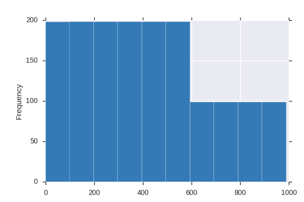

margin1  
Numeric

| Distinct count | 46 |
| --- | --- |
| Unique (%) | 2.9% |
| Missing (%) | 0.0% |
| Missing (n) | 0 |
| Infinite (%) | 0.0% |
| Infinite (n) | 0 |

| Mean | 0.017468 |
| --- | --- |
| Minimum | 0 |
| Maximum | 0.087891 |
| Zeros (%) | 20.6% |

Toggle details

Quantile statistics

| Minimum | 0 |
| --- | --- |
| 5-th percentile | 0 |
| Q1 | 0.001953 |
| Median | 0.009766 |
| Q3 | 0.027344 |
| 95-th percentile | 0.060547 |
| Maximum | 0.087891 |
| Range | 0.087891 |
| Interquartile range | 0.025391 |

Descriptive statistics

| Standard deviation | 0.019675 |
| --- | --- |
| Coef of variation | 1.1263 |
| Kurtosis | 0.81844 |
| Mean | 0.017468 |
| MAD | 0.015664 |
| Skewness | 1.2789 |
| Sum | 27.67 |
| Variance | 0.00038711 |
| Memory size | 12.5 KiB |

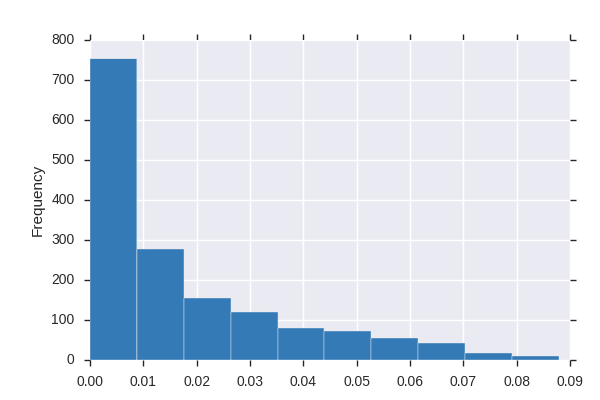

margin10  
Numeric

| Distinct count | 44 |
| --- | --- |
| Unique (%) | 2.8% |
| Missing (%) | 0.0% |
| Missing (n) | 0 |
| Infinite (%) | 0.0% |
| Infinite (n) | 0 |

| Mean | 0.018699 |
| --- | --- |
| Minimum | 0 |
| Maximum | 0.097656 |
| Zeros (%) | 9.7% |

Toggle details

Quantile statistics

| Minimum | 0 |
| --- | --- |
| 5-th percentile | 0 |
| Q1 | 0.005859 |
| Median | 0.015625 |
| Q3 | 0.027344 |
| 95-th percentile | 0.050781 |
| Maximum | 0.097656 |
| Range | 0.097656 |
| Interquartile range | 0.021485 |

Descriptive statistics

| Standard deviation | 0.016126 |
| --- | --- |
| Coef of variation | 0.86238 |
| Kurtosis | 1.1182 |
| Mean | 0.018699 |
| MAD | 0.012772 |
| Skewness | 1.1141 |
| Sum | 29.619 |
| Variance | 0.00026004 |
| Memory size | 12.5 KiB |

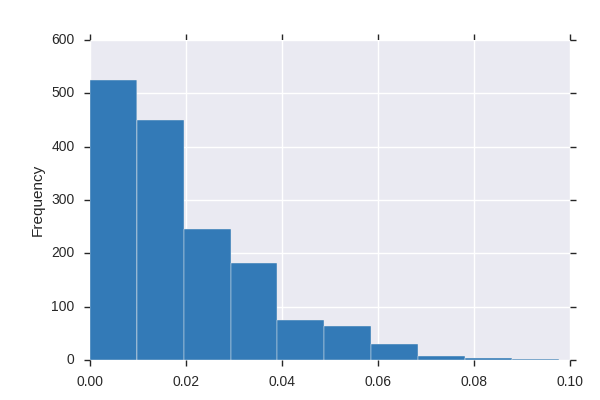

margin11  
Numeric

| Distinct count | 58 |
| --- | --- |
| Unique (%) | 3.7% |
| Missing (%) | 0.0% |
| Missing (n) | 0 |
| Infinite (%) | 0.0% |
| Infinite (n) | 0 |

| Mean | 0.024254 |
| --- | --- |
| Minimum | 0 |
| Maximum | 0.125 |
| Zeros (%) | 15.2% |

Toggle details

Quantile statistics

| Minimum | 0 |
| --- | --- |
| 5-th percentile | 0 |
| Q1 | 0.003906 |
| Median | 0.013672 |
| Q3 | 0.041016 |
| 95-th percentile | 0.076172 |
| Maximum | 0.125 |
| Range | 0.125 |
| Interquartile range | 0.03711 |

Descriptive statistics

| Standard deviation | 0.026013 |
| --- | --- |
| Coef of variation | 1.0725 |
| Kurtosis | 0.24217 |
| Mean | 0.024254 |
| MAD | 0.021493 |
| Skewness | 1.1092 |
| Sum | 38.418 |
| Variance | 0.00067665 |
| Memory size | 12.5 KiB |

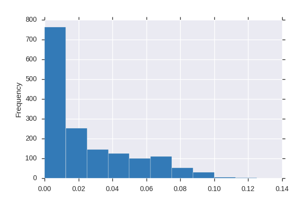

margin12  
Numeric

| Distinct count | 30 |
| --- | --- |
| Unique (%) | 1.9% |
| Missing (%) | 0.0% |
| Missing (n) | 0 |
| Infinite (%) | 0.0% |
| Infinite (n) | 0 |

| Mean | 0.01209 |
| --- | --- |
| Minimum | 0 |
| Maximum | 0.056641 |
| Zeros (%) | 15.4% |

Toggle details

Quantile statistics

| Minimum | 0 |
| --- | --- |
| 5-th percentile | 0 |
| Q1 | 0.001953 |
| Median | 0.007812 |
| Q3 | 0.019531 |
| 95-th percentile | 0.037109 |
| Maximum | 0.056641 |
| Range | 0.056641 |
| Interquartile range | 0.017578 |

Descriptive statistics

| Standard deviation | 0.011909 |
| --- | --- |
| Coef of variation | 0.98507 |
| Kurtosis | 0.40048 |
| Mean | 0.01209 |
| MAD | 0.0097688 |
| Skewness | 1.0457 |
| Sum | 19.15 |
| Variance | 0.00014183 |
| Memory size | 12.5 KiB |

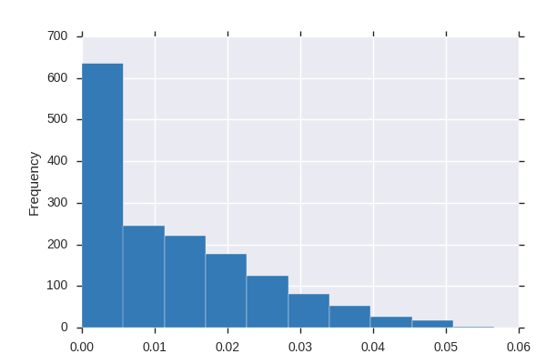

margin13  
Numeric

| Distinct count | 93 |
| --- | --- |
| Unique (%) | 5.9% |
| Missing (%) | 0.0% |
| Missing (n) | 0 |
| Infinite (%) | 0.0% |
| Infinite (n) | 0 |

| Mean | 0.041373 |
| --- | --- |
| Minimum | 0 |
| Maximum | 0.41602 |
| Zeros (%) | 9.0% |

Toggle details

Quantile statistics

| Minimum | 0 |
| --- | --- |
| 5-th percentile | 0 |
| Q1 | 0.009766 |
| Median | 0.027344 |
| Q3 | 0.064453 |
| 95-th percentile | 0.11523 |
| Maximum | 0.41602 |
| Range | 0.41602 |
| Interquartile range | 0.054687 |

Descriptive statistics

| Standard deviation | 0.046517 |
| --- | --- |
| Coef of variation | 1.1243 |
| Kurtosis | 16.05 |
| Mean | 0.041373 |
| MAD | 0.033276 |
| Skewness | 2.9773 |
| Sum | 65.535 |
| Variance | 0.0021638 |
| Memory size | 12.5 KiB |

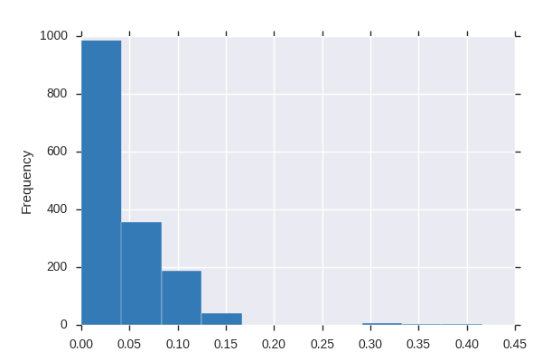

margin14  
Numeric

| Distinct count | 39 |
| --- | --- |
| Unique (%) | 2.5% |
| Missing (%) | 0.0% |
| Missing (n) | 0 |
| Infinite (%) | 0.0% |
| Infinite (n) | 0 |

| Mean | 0.0077619 |
| --- | --- |
| Minimum | 0 |
| Maximum | 0.082031 |
| Zeros (%) | 31.1% |

Toggle details

Quantile statistics

| Minimum | 0 |
| --- | --- |
| 5-th percentile | 0 |
| Q1 | 0 |
| Median | 0.001953 |
| Q3 | 0.007812 |
| 95-th percentile | 0.037109 |
| Maximum | 0.082031 |
| Range | 0.082031 |
| Interquartile range | 0.007812 |

Descriptive statistics

| Standard deviation | 0.012782 |
| --- | --- |
| Coef of variation | 1.6467 |
| Kurtosis | 6.8579 |
| Mean | 0.0077619 |
| MAD | 0.008781 |
| Skewness | 2.5154 |
| Sum | 12.295 |
| Variance | 0.00016337 |
| Memory size | 12.5 KiB |

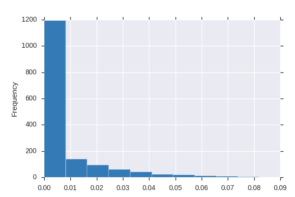

margin15  
Numeric

| Distinct count | 35 |
| --- | --- |
| Unique (%) | 2.2% |
| Missing (%) | 0.0% |
| Missing (n) | 0 |
| Infinite (%) | 0.0% |
| Infinite (n) | 0 |

| Mean | 0.015666 |
| --- | --- |
| Minimum | 0 |
| Maximum | 0.066406 |
| Zeros (%) | 13.8% |

Toggle details

Quantile statistics

| Minimum | 0 |
| --- | --- |
| 5-th percentile | 0 |
| Q1 | 0.001953 |
| Median | 0.011719 |
| Q3 | 0.025391 |
| 95-th percentile | 0.041016 |
| Maximum | 0.066406 |
| Range | 0.066406 |
| Interquartile range | 0.023438 |

Descriptive statistics

| Standard deviation | 0.01437 |
| --- | --- |
| Coef of variation | 0.9173 |
| Kurtosis | -0.097595 |
| Mean | 0.015666 |
| MAD | 0.012032 |
| Skewness | 0.80993 |
| Sum | 24.814 |
| Variance | 0.0002065 |
| Memory size | 12.5 KiB |

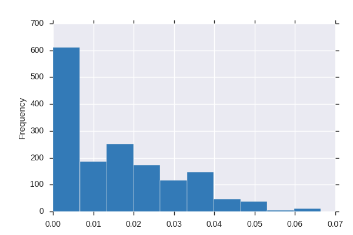

margin16  
Numeric

| Distinct count | 12 |
| --- | --- |
| Unique (%) | 0.8% |
| Missing (%) | 0.0% |
| Missing (n) | 0 |
| Infinite (%) | 0.0% |
| Infinite (n) | 0 |

| Mean | 0.00015659 |
| --- | --- |
| Minimum | 0 |
| Maximum | 0.029297 |
| Zeros (%) | 98.5% |

Toggle details

Quantile statistics

| Minimum | 0 |
| --- | --- |
| 5-th percentile | 0 |
| Q1 | 0 |
| Median | 0 |
| Q3 | 0 |
| 95-th percentile | 0 |
| Maximum | 0.029297 |
| Range | 0.029297 |
| Interquartile range | 0 |

Descriptive statistics

| Standard deviation | 0.0015057 |
| --- | --- |
| Coef of variation | 9.6154 |
| Kurtosis | 180.51 |
| Mean | 0.00015659 |
| MAD | 0.00030844 |
| Skewness | 12.386 |
| Sum | 0.24804 |
| Variance | 2.2672e-06 |
| Memory size | 12.5 KiB |

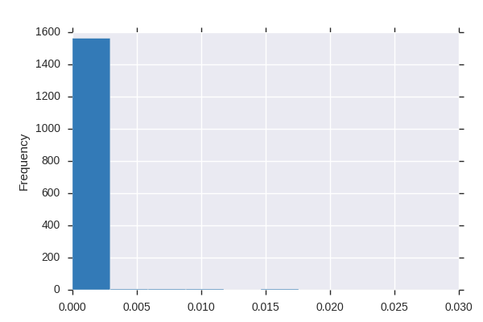

margin17  
Numeric

| Distinct count | 31 |
| --- | --- |
| Unique (%) | 2.0% |
| Missing (%) | 0.0% |
| Missing (n) | 0 |
| Infinite (%) | 0.0% |
| Infinite (n) | 0 |

| Mean | 0.015048 |
| --- | --- |
| Minimum | 0 |
| Maximum | 0.064453 |
| Zeros (%) | 5.7% |

Toggle details

Quantile statistics

| Minimum | 0 |
| --- | --- |
| 5-th percentile | 0 |
| Q1 | 0.005859 |
| Median | 0.013672 |
| Q3 | 0.021484 |
| 95-th percentile | 0.035156 |
| Maximum | 0.064453 |
| Range | 0.064453 |
| Interquartile range | 0.015625 |

Descriptive statistics

| Standard deviation | 0.010851 |
| --- | --- |
| Coef of variation | 0.72112 |
| Kurtosis | 0.73108 |
| Mean | 0.015048 |
| MAD | 0.008703 |
| Skewness | 0.85941 |
| Sum | 23.836 |
| Variance | 0.00011775 |
| Memory size | 12.5 KiB |

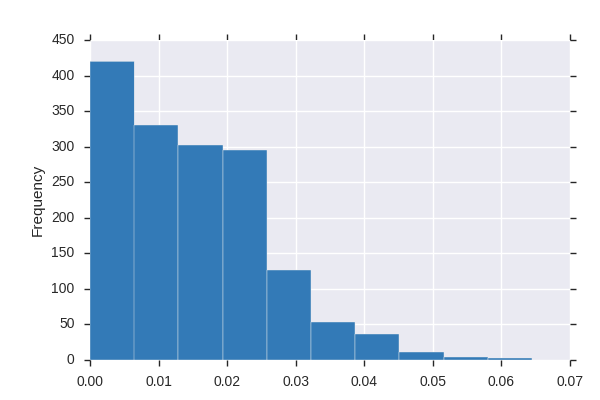

margin18  
Numeric

| Distinct count | 60 |
| --- | --- |
| Unique (%) | 3.8% |
| Missing (%) | 0.0% |
| Missing (n) | 0 |
| Infinite (%) | 0.0% |
| Infinite (n) | 0 |

| Mean | 0.02034 |
| --- | --- |
| Minimum | 0 |
| Maximum | 0.35938 |
| Zeros (%) | 7.3% |

Toggle details

Quantile statistics

| Minimum | 0 |
| --- | --- |
| 5-th percentile | 0 |
| Q1 | 0.005859 |
| Median | 0.015625 |
| Q3 | 0.027832 |
| 95-th percentile | 0.050781 |
| Maximum | 0.35938 |
| Range | 0.35938 |
| Interquartile range | 0.021973 |

Descriptive statistics

| Standard deviation | 0.022732 |
| --- | --- |
| Coef of variation | 1.1176 |
| Kurtosis | 48.848 |
| Mean | 0.02034 |
| MAD | 0.014239 |
| Skewness | 5.0219 |
| Sum | 32.219 |
| Variance | 0.00051676 |
| Memory size | 12.5 KiB |

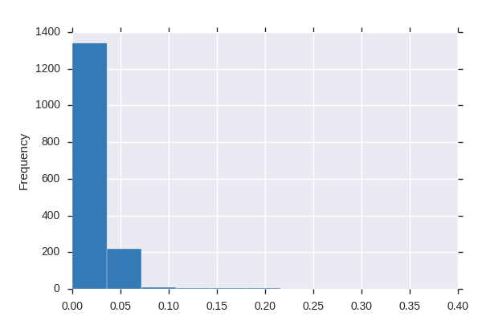

margin19  
Numeric

| Distinct count | 47 |
| --- | --- |
| Unique (%) | 3.0% |
| Missing (%) | 0.0% |
| Missing (n) | 0 |
| Infinite (%) | 0.0% |
| Infinite (n) | 0 |

| Mean | 0.012582 |
| --- | --- |
| Minimum | 0 |
| Maximum | 0.125 |
| Zeros (%) | 11.1% |

Toggle details

Quantile statistics

| Minimum | 0 |
| --- | --- |
| 5-th percentile | 0 |
| Q1 | 0.003906 |
| Median | 0.007812 |
| Q3 | 0.017578 |
| 95-th percentile | 0.037109 |
| Maximum | 0.125 |
| Range | 0.125 |
| Interquartile range | 0.013672 |

Descriptive statistics

| Standard deviation | 0.014185 |
| --- | --- |
| Coef of variation | 1.1274 |
| Kurtosis | 13.239 |
| Mean | 0.012582 |
| MAD | 0.0096097 |
| Skewness | 2.9133 |
| Sum | 19.93 |
| Variance | 0.00020121 |
| Memory size | 12.5 KiB |

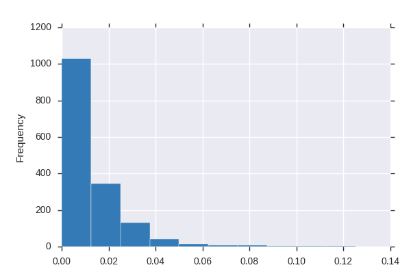

margin2  
Numeric

| Distinct count | 90 |
| --- | --- |
| Unique (%) | 5.7% |
| Missing (%) | 0.0% |
| Missing (n) | 0 |
| Infinite (%) | 0.0% |
| Infinite (n) | 0 |

| Mean | 0.028497 |
| --- | --- |
| Minimum | 0 |
| Maximum | 0.20508 |
| Zeros (%) | 21.4% |

Toggle details

Quantile statistics

| Minimum | 0 |
| --- | --- |
| 5-th percentile | 0 |
| Q1 | 0.001953 |
| Median | 0.011719 |
| Q3 | 0.041016 |
| 95-th percentile | 0.11523 |
| Maximum | 0.20508 |
| Range | 0.20508 |
| Interquartile range | 0.039063 |

Descriptive statistics

| Standard deviation | 0.038655 |
| --- | --- |
| Coef of variation | 1.3565 |
| Kurtosis | 2.4781 |
| Mean | 0.028497 |
| MAD | 0.029494 |
| Skewness | 1.7315 |
| Sum | 45.139 |
| Variance | 0.0014942 |
| Memory size | 12.5 KiB |

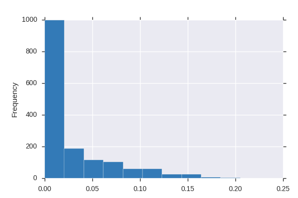

margin20  
Numeric

| Distinct count | 30 |
| --- | --- |
| Unique (%) | 1.9% |
| Missing (%) | 0.0% |
| Missing (n) | 0 |
| Infinite (%) | 0.0% |
| Infinite (n) | 0 |

| Mean | 0.013223 |
| --- | --- |
| Minimum | 0 |
| Maximum | 0.056641 |
| Zeros (%) | 3.9% |

Toggle details

Quantile statistics

| Minimum | 0 |
| --- | --- |
| 5-th percentile | 0.001953 |
| Q1 | 0.005859 |
| Median | 0.011719 |
| Q3 | 0.017578 |
| 95-th percentile | 0.033203 |
| Maximum | 0.056641 |
| Range | 0.056641 |
| Interquartile range | 0.011719 |

Descriptive statistics

| Standard deviation | 0.0099507 |
| --- | --- |
| Coef of variation | 0.75253 |
| Kurtosis | 1.6532 |
| Mean | 0.013223 |
| MAD | 0.0076615 |
| Skewness | 1.2313 |
| Sum | 20.945 |
| Variance | 9.9016e-05 |
| Memory size | 12.5 KiB |

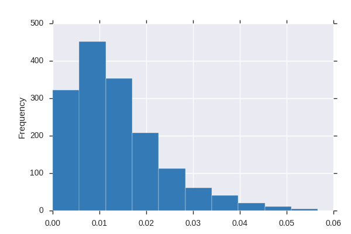

margin21  
Numeric

| Distinct count | 50 |
| --- | --- |
| Unique (%) | 3.2% |
| Missing (%) | 0.0% |
| Missing (n) | 0 |
| Infinite (%) | 0.0% |
| Infinite (n) | 0 |

| Mean | 0.019021 |
| --- | --- |
| Minimum | 0 |
| Maximum | 0.10156 |
| Zeros (%) | 17.7% |

Toggle details

Quantile statistics

| Minimum | 0 |
| --- | --- |
| 5-th percentile | 0 |
| Q1 | 0.003906 |
| Median | 0.013672 |
| Q3 | 0.03125 |
| 95-th percentile | 0.056641 |
| Maximum | 0.10156 |
| Range | 0.10156 |
| Interquartile range | 0.027344 |

Descriptive statistics

| Standard deviation | 0.019174 |
| --- | --- |
| Coef of variation | 1.0081 |
| Kurtosis | 0.89833 |
| Mean | 0.019021 |
| MAD | 0.015776 |
| Skewness | 1.1226 |
| Sum | 30.129 |
| Variance | 0.00036764 |
| Memory size | 12.5 KiB |

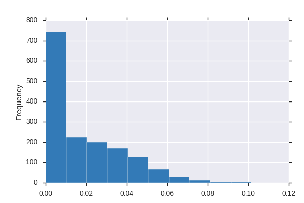

margin22  
Numeric

| Distinct count | 32 |
| --- | --- |
| Unique (%) | 2.0% |
| Missing (%) | 0.0% |
| Missing (n) | 0 |
| Infinite (%) | 0.0% |
| Infinite (n) | 0 |

| Mean | 0.0062009 |
| --- | --- |
| Minimum | 0 |
| Maximum | 0.0625 |
| Zeros (%) | 46.3% |

Toggle details

Quantile statistics

| Minimum | 0 |
| --- | --- |
| 5-th percentile | 0 |
| Q1 | 0 |
| Median | 0.001953 |
| Q3 | 0.007812 |
| 95-th percentile | 0.027344 |
| Maximum | 0.0625 |
| Range | 0.0625 |
| Interquartile range | 0.007812 |

Descriptive statistics

| Standard deviation | 0.010279 |
| --- | --- |
| Coef of variation | 1.6577 |
| Kurtosis | 5.8223 |
| Mean | 0.0062009 |
| MAD | 0.0073713 |
| Skewness | 2.306 |
| Sum | 9.8222 |
| Variance | 0.00010566 |
| Memory size | 12.5 KiB |

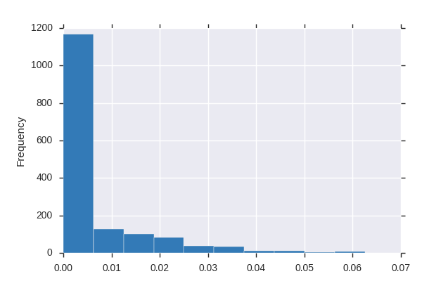

margin23  
Numeric

| Distinct count | 23 |
| --- | --- |
| Unique (%) | 1.5% |
| Missing (%) | 0.0% |
| Missing (n) | 0 |
| Infinite (%) | 0.0% |
| Infinite (n) | 0 |

| Mean | 0.0010444 |
| --- | --- |
| Minimum | 0 |
| Maximum | 0.046875 |
| Zeros (%) | 91.7% |

Toggle details

Quantile statistics

| Minimum | 0 |
| --- | --- |
| 5-th percentile | 0 |
| Q1 | 0 |
| Median | 0 |
| Q3 | 0 |
| 95-th percentile | 0.007812 |
| Maximum | 0.046875 |
| Range | 0.046875 |
| Interquartile range | 0 |

Descriptive statistics

| Standard deviation | 0.0044604 |
| --- | --- |
| Coef of variation | 4.2709 |
| Kurtosis | 35.28 |
| Mean | 0.0010444 |
| MAD | 0.0019147 |
| Skewness | 5.5286 |
| Sum | 1.6543 |
| Variance | 1.9895e-05 |
| Memory size | 12.5 KiB |

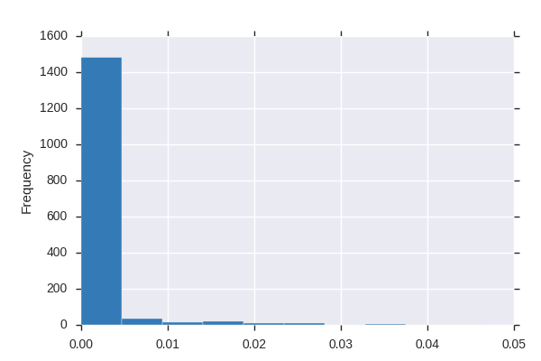

margin24  
Numeric

| Distinct count | 36 |
| --- | --- |
| Unique (%) | 2.3% |
| Missing (%) | 0.0% |
| Missing (n) | 0 |
| Infinite (%) | 0.0% |
| Infinite (n) | 0 |

| Mean | 0.0074931 |
| --- | --- |
| Minimum | 0 |
| Maximum | 0.078125 |
| Zeros (%) | 48.5% |

Toggle details

Quantile statistics

| Minimum | 0 |
| --- | --- |
| 5-th percentile | 0 |
| Q1 | 0 |
| Median | 0.001953 |
| Q3 | 0.009766 |
| 95-th percentile | 0.037109 |
| Maximum | 0.078125 |
| Range | 0.078125 |
| Interquartile range | 0.009766 |

Descriptive statistics

| Standard deviation | 0.012496 |
| --- | --- |
| Coef of variation | 1.6677 |
| Kurtosis | 5.2254 |
| Mean | 0.0074931 |
| MAD | 0.0087397 |
| Skewness | 2.2812 |
| Sum | 11.869 |
| Variance | 0.00015615 |
| Memory size | 12.5 KiB |

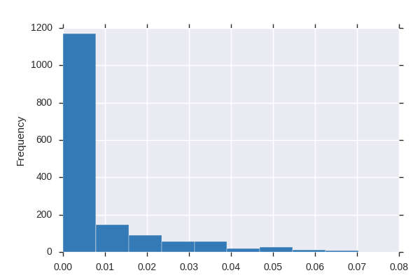

margin25  
Numeric

| Distinct count | 37 |
| --- | --- |
| Unique (%) | 2.3% |
| Missing (%) | 0.0% |
| Missing (n) | 0 |
| Infinite (%) | 0.0% |
| Infinite (n) | 0 |

| Mean | 0.0089764 |
| --- | --- |
| Minimum | 0 |
| Maximum | 0.082031 |
| Zeros (%) | 30.7% |

Toggle details

Quantile statistics

| Minimum | 0 |
| --- | --- |
| 5-th percentile | 0 |
| Q1 | 0 |
| Median | 0.001953 |
| Q3 | 0.013672 |
| 95-th percentile | 0.036816 |
| Maximum | 0.082031 |
| Range | 0.082031 |
| Interquartile range | 0.013672 |

Descriptive statistics

| Standard deviation | 0.012688 |
| --- | --- |
| Coef of variation | 1.4134 |
| Kurtosis | 3.9267 |
| Mean | 0.0089764 |
| MAD | 0.0095794 |
| Skewness | 1.9362 |
| Sum | 14.219 |
| Variance | 0.00016097 |
| Memory size | 12.5 KiB |

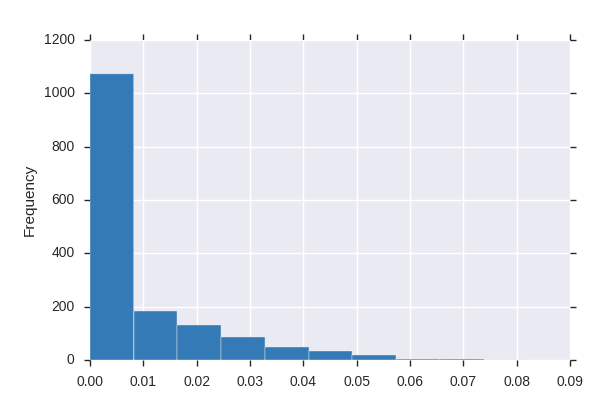

margin26  
Numeric

| Distinct count | 37 |
| --- | --- |
| Unique (%) | 2.3% |
| Missing (%) | 0.0% |
| Missing (n) | 0 |
| Infinite (%) | 0.0% |
| Infinite (n) | 0 |

| Mean | 0.018562 |
| --- | --- |
| Minimum | 0 |
| Maximum | 0.085938 |
| Zeros (%) | 2.0% |

Toggle details

Quantile statistics

| Minimum | 0 |
| --- | --- |
| 5-th percentile | 0.001953 |
| Q1 | 0.009766 |
| Median | 0.015625 |
| Q3 | 0.025391 |
| 95-th percentile | 0.041016 |
| Maximum | 0.085938 |
| Range | 0.085938 |
| Interquartile range | 0.015625 |

Descriptive statistics

| Standard deviation | 0.01208 |
| --- | --- |
| Coef of variation | 0.65079 |
| Kurtosis | 1.6026 |
| Mean | 0.018562 |
| MAD | 0.0094952 |
| Skewness | 1.0158 |
| Sum | 29.402 |
| Variance | 0.00014593 |
| Memory size | 12.5 KiB |

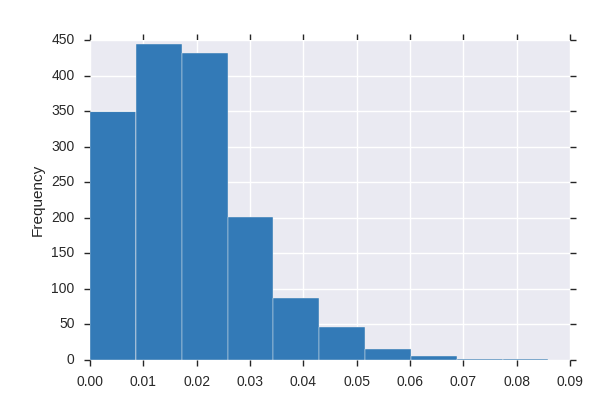

margin27  
Numeric

| Distinct count | 35 |
| --- | --- |
| Unique (%) | 2.2% |
| Missing (%) | 0.0% |
| Missing (n) | 0 |
| Infinite (%) | 0.0% |
| Infinite (n) | 0 |

| Mean | 0.0056065 |
| --- | --- |
| Minimum | 0 |
| Maximum | 0.082031 |
| Zeros (%) | 52.7% |

Toggle details

Quantile statistics

| Minimum | 0 |
| --- | --- |
| 5-th percentile | 0 |
| Q1 | 0 |
| Median | 0 |
| Q3 | 0.005859 |
| 95-th percentile | 0.03125 |
| Maximum | 0.082031 |
| Range | 0.082031 |
| Interquartile range | 0.005859 |

Descriptive statistics

| Standard deviation | 0.010965 |
| --- | --- |
| Coef of variation | 1.9557 |
| Kurtosis | 8.3345 |
| Mean | 0.0056065 |
| MAD | 0.0072137 |
| Skewness | 2.7683 |
| Sum | 8.8808 |
| Variance | 0.00012023 |
| Memory size | 12.5 KiB |

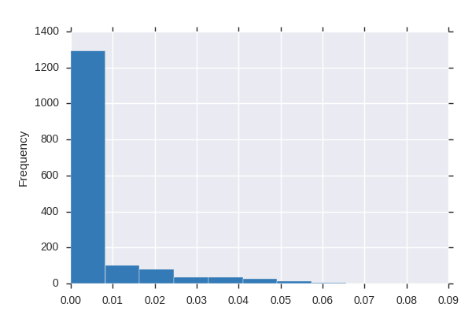

margin28  
Numeric

| Distinct count | 38 |
| --- | --- |
| Unique (%) | 2.4% |
| Missing (%) | 0.0% |
| Missing (n) | 0 |
| Infinite (%) | 0.0% |
| Infinite (n) | 0 |

| Mean | 0.015449 |
| --- | --- |
| Minimum | 0 |
| Maximum | 0.080078 |
| Zeros (%) | 8.7% |

Toggle details

Quantile statistics

| Minimum | 0 |
| --- | --- |
| 5-th percentile | 0 |
| Q1 | 0.003906 |
| Median | 0.011719 |
| Q3 | 0.023438 |
| 95-th percentile | 0.042969 |
| Maximum | 0.080078 |
| Range | 0.080078 |
| Interquartile range | 0.019532 |

Descriptive statistics

| Standard deviation | 0.01401 |
| --- | --- |
| Coef of variation | 0.90689 |
| Kurtosis | 1.4424 |
| Mean | 0.015449 |
| MAD | 0.011163 |
| Skewness | 1.2095 |
| Sum | 24.471 |
| Variance | 0.00019628 |
| Memory size | 12.5 KiB |

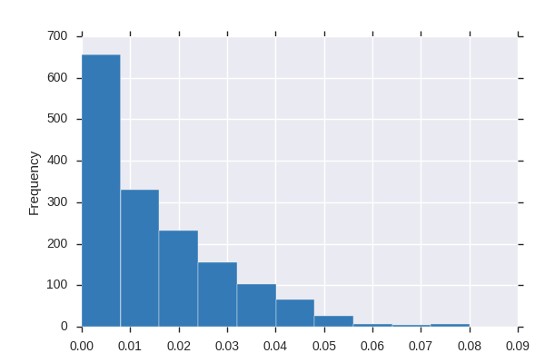

margin29  
Numeric

| Distinct count | 63 |
| --- | --- |
| Unique (%) | 4.0% |
| Missing (%) | 0.0% |
| Missing (n) | 0 |
| Infinite (%) | 0.0% |
| Infinite (n) | 0 |

| Mean | 0.028416 |
| --- | --- |
| Minimum | 0 |
| Maximum | 0.14844 |
| Zeros (%) | 4.2% |

Toggle details

Quantile statistics

| Minimum | 0 |
| --- | --- |
| 5-th percentile | 0.001953 |
| Q1 | 0.009766 |
| Median | 0.023438 |
| Q3 | 0.041016 |
| 95-th percentile | 0.072266 |
| Maximum | 0.14844 |
| Range | 0.14844 |
| Interquartile range | 0.03125 |

Descriptive statistics

| Standard deviation | 0.023 |
| --- | --- |
| Coef of variation | 0.80939 |
| Kurtosis | 2.3555 |
| Mean | 0.028416 |
| MAD | 0.017732 |
| Skewness | 1.2953 |
| Sum | 45.012 |
| Variance | 0.000529 |
| Memory size | 12.5 KiB |

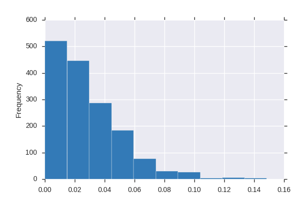

margin3  
Numeric

| Distinct count | 69 |
| --- | --- |
| Unique (%) | 4.4% |
| Missing (%) | 0.0% |
| Missing (n) | 0 |
| Infinite (%) | 0.0% |
| Infinite (n) | 0 |

| Mean | 0.031939 |
| --- | --- |
| Minimum | 0 |
| Maximum | 0.16797 |
| Zeros (%) | 2.2% |

Toggle details

Quantile statistics

| Minimum | 0 |
| --- | --- |
| 5-th percentile | 0.003906 |
| Q1 | 0.013672 |
| Median | 0.023438 |
| Q3 | 0.044922 |
| 95-th percentile | 0.083984 |
| Maximum | 0.16797 |
| Range | 0.16797 |
| Interquartile range | 0.03125 |

Descriptive statistics

| Standard deviation | 0.025791 |
| --- | --- |
| Coef of variation | 0.80749 |
| Kurtosis | 2.1851 |
| Mean | 0.031939 |
| MAD | 0.019849 |
| Skewness | 1.4054 |
| Sum | 50.592 |
| Variance | 0.00066516 |
| Memory size | 12.5 KiB |

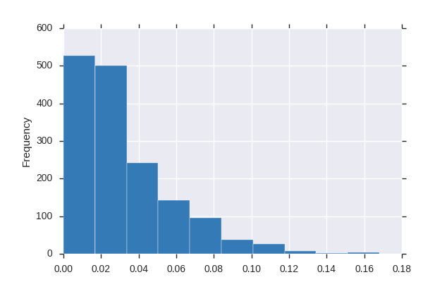

margin30  
Numeric

| Distinct count | 49 |
| --- | --- |
| Unique (%) | 3.1% |
| Missing (%) | 0.0% |
| Missing (n) | 0 |
| Infinite (%) | 0.0% |
| Infinite (n) | 0 |

| Mean | 0.016293 |
| --- | --- |
| Minimum | 0 |
| Maximum | 0.11914 |
| Zeros (%) | 6.6% |

Toggle details

Quantile statistics

| Minimum | 0 |
| --- | --- |
| 5-th percentile | 0 |
| Q1 | 0.005859 |
| Median | 0.011719 |
| Q3 | 0.021484 |
| 95-th percentile | 0.050781 |
| Maximum | 0.11914 |
| Range | 0.11914 |
| Interquartile range | 0.015625 |

Descriptive statistics

| Standard deviation | 0.016332 |
| --- | --- |
| Coef of variation | 1.0024 |
| Kurtosis | 4.8002 |
| Mean | 0.016293 |
| MAD | 0.011931 |
| Skewness | 1.9452 |
| Sum | 25.808 |
| Variance | 0.00026672 |
| Memory size | 12.5 KiB |

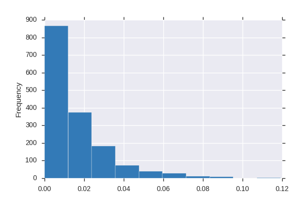

margin31  
Numeric

| Distinct count | 49 |
| --- | --- |
| Unique (%) | 3.1% |
| Missing (%) | 0.0% |
| Missing (n) | 0 |
| Infinite (%) | 0.0% |
| Infinite (n) | 0 |

| Mean | 0.010973 |
| --- | --- |
| Minimum | 0 |
| Maximum | 0.11328 |
| Zeros (%) | 32.0% |

Toggle details

Quantile statistics

| Minimum | 0 |
| --- | --- |
| 5-th percentile | 0 |
| Q1 | 0 |
| Median | 0.003906 |
| Q3 | 0.013672 |
| 95-th percentile | 0.048535 |
| Maximum | 0.11328 |
| Range | 0.11328 |
| Interquartile range | 0.013672 |

Descriptive statistics

| Standard deviation | 0.01663 |
| --- | --- |
| Coef of variation | 1.5156 |
| Kurtosis | 4.7235 |
| Mean | 0.010973 |
| MAD | 0.012156 |
| Skewness | 2.1178 |
| Sum | 17.381 |
| Variance | 0.00027655 |
| Memory size | 12.5 KiB |

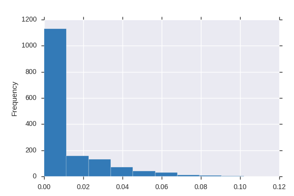

margin32  
Numeric

| Distinct count | 54 |
| --- | --- |
| Unique (%) | 3.4% |
| Missing (%) | 0.0% |
| Missing (n) | 0 |
| Infinite (%) | 0.0% |
| Infinite (n) | 0 |

| Mean | 0.0098174 |
| --- | --- |
| Minimum | 0 |
| Maximum | 0.12695 |
| Zeros (%) | 46.5% |

Toggle details

Quantile statistics

| Minimum | 0 |
| --- | --- |
| 5-th percentile | 0 |
| Q1 | 0 |
| Median | 0.001953 |
| Q3 | 0.009766 |
| 95-th percentile | 0.056641 |
| Maximum | 0.12695 |
| Range | 0.12695 |
| Interquartile range | 0.009766 |

Descriptive statistics

| Standard deviation | 0.019243 |
| --- | --- |
| Coef of variation | 1.9601 |
| Kurtosis | 7.8568 |
| Mean | 0.0098174 |
| MAD | 0.012701 |
| Skewness | 2.7264 |
| Sum | 15.551 |
| Variance | 0.0003703 |
| Memory size | 12.5 KiB |

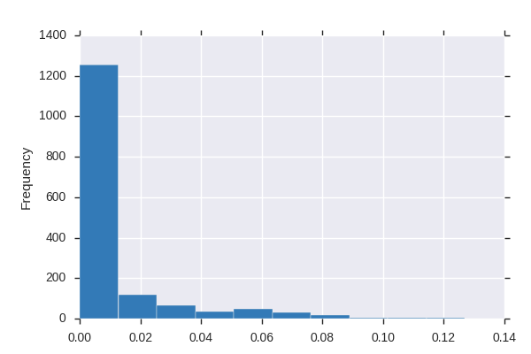

margin33  
Numeric

| Distinct count | 42 |
| --- | --- |
| Unique (%) | 2.7% |
| Missing (%) | 0.0% |
| Missing (n) | 0 |
| Infinite (%) | 0.0% |
| Infinite (n) | 0 |

| Mean | 0.019507 |
| --- | --- |
| Minimum | 0 |
| Maximum | 0.083984 |
| Zeros (%) | 6.0% |

Toggle details

Quantile statistics

| Minimum | 0 |
| --- | --- |
| 5-th percentile | 0 |
| Q1 | 0.005859 |
| Median | 0.015625 |
| Q3 | 0.029297 |
| 95-th percentile | 0.048828 |
| Maximum | 0.083984 |
| Range | 0.083984 |
| Interquartile range | 0.023438 |

Descriptive statistics

| Standard deviation | 0.015983 |
| --- | --- |
| Coef of variation | 0.81937 |
| Kurtosis | 0.16353 |
| Mean | 0.019507 |
| MAD | 0.013166 |
| Skewness | 0.86779 |
| Sum | 30.898 |
| Variance | 0.00025546 |
| Memory size | 12.5 KiB |

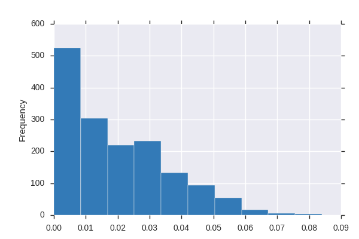

margin34  
Numeric

| Distinct count | 12 |
| --- | --- |
| Unique (%) | 0.8% |
| Missing (%) | 0.0% |
| Missing (n) | 0 |
| Infinite (%) | 0.0% |
| Infinite (n) | 0 |

| Mean | 0.0011306 |
| --- | --- |
| Minimum | 0 |
| Maximum | 0.029297 |
| Zeros (%) | 68.8% |

Toggle details

Quantile statistics

| Minimum | 0 |
| --- | --- |
| 5-th percentile | 0 |
| Q1 | 0 |
| Median | 0 |
| Q3 | 0.001953 |
| 95-th percentile | 0.005859 |
| Maximum | 0.029297 |
| Range | 0.029297 |
| Interquartile range | 0.001953 |

Descriptive statistics

| Standard deviation | 0.0022804 |
| --- | --- |
| Coef of variation | 2.0169 |
| Kurtosis | 24.142 |
| Mean | 0.0011306 |
| MAD | 0.0015546 |
| Skewness | 3.6668 |
| Sum | 1.7909 |
| Variance | 5.2002e-06 |
| Memory size | 12.5 KiB |

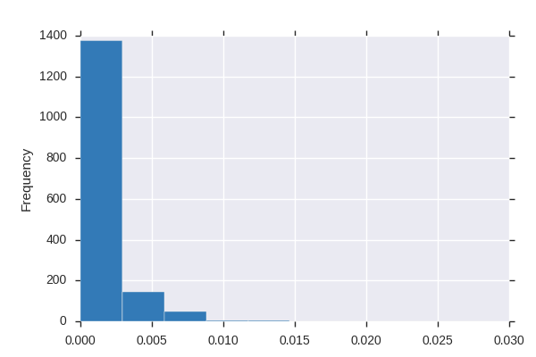

margin35  
Numeric

| Distinct count | 37 |
| --- | --- |
| Unique (%) | 2.3% |
| Missing (%) | 0.0% |
| Missing (n) | 0 |
| Infinite (%) | 0.0% |
| Infinite (n) | 0 |

| Mean | 0.013499 |
| --- | --- |
| Minimum | 0 |
| Maximum | 0.082031 |
| Zeros (%) | 19.1% |

Toggle details

Quantile statistics

| Minimum | 0 |
| --- | --- |
| 5-th percentile | 0 |
| Q1 | 0.001953 |
| Median | 0.009766 |
| Q3 | 0.021484 |
| 95-th percentile | 0.041016 |
| Maximum | 0.082031 |
| Range | 0.082031 |
| Interquartile range | 0.019531 |

Descriptive statistics

| Standard deviation | 0.013619 |
| --- | --- |
| Coef of variation | 1.0089 |
| Kurtosis | 1.2197 |
| Mean | 0.013499 |
| MAD | 0.010953 |
| Skewness | 1.2022 |
| Sum | 21.383 |
| Variance | 0.00018549 |
| Memory size | 12.5 KiB |

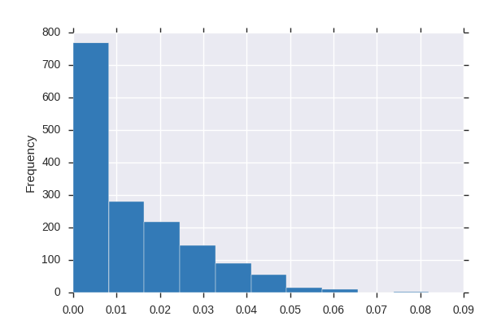

margin36  
Numeric

| Distinct count | 41 |
| --- | --- |
| Unique (%) | 2.6% |
| Missing (%) | 0.0% |
| Missing (n) | 0 |
| Infinite (%) | 0.0% |
| Infinite (n) | 0 |

| Mean | 0.017921 |
| --- | --- |
| Minimum | 0 |
| Maximum | 0.089844 |
| Zeros (%) | 9.4% |

Toggle details

Quantile statistics

| Minimum | 0 |
| --- | --- |
| 5-th percentile | 0 |
| Q1 | 0.003906 |
| Median | 0.013672 |
| Q3 | 0.027344 |
| 95-th percentile | 0.050781 |
| Maximum | 0.089844 |
| Range | 0.089844 |
| Interquartile range | 0.023438 |

Descriptive statistics

| Standard deviation | 0.016166 |
| --- | --- |
| Coef of variation | 0.90209 |
| Kurtosis | 0.65102 |
| Mean | 0.017921 |
| MAD | 0.013018 |
| Skewness | 1.0689 |
| Sum | 28.387 |
| Variance | 0.00026135 |
| Memory size | 12.5 KiB |

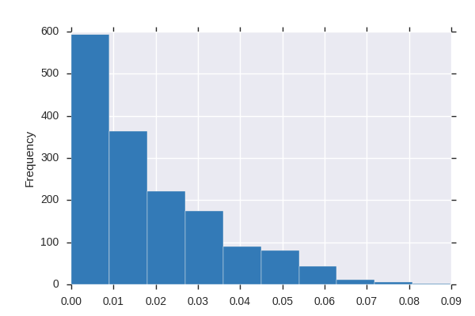

margin37  
Numeric

| Distinct count | 33 |
| --- | --- |
| Unique (%) | 2.1% |
| Missing (%) | 0.0% |
| Missing (n) | 0 |
| Infinite (%) | 0.0% |
| Infinite (n) | 0 |

| Mean | 0.016081 |
| --- | --- |
| Minimum | 0 |
| Maximum | 0.068359 |
| Zeros (%) | 3.4% |

Toggle details

Quantile statistics

| Minimum | 0 |
| --- | --- |
| 5-th percentile | 0.001953 |
| Q1 | 0.007812 |
| Median | 0.013672 |
| Q3 | 0.021484 |
| 95-th percentile | 0.037109 |
| Maximum | 0.068359 |
| Range | 0.068359 |
| Interquartile range | 0.013672 |

Descriptive statistics

| Standard deviation | 0.011326 |
| --- | --- |
| Coef of variation | 0.7043 |
| Kurtosis | 1.5266 |
| Mean | 0.016081 |
| MAD | 0.0088852 |
| Skewness | 1.0922 |
| Sum | 25.473 |
| Variance | 0.00012828 |
| Memory size | 12.5 KiB |

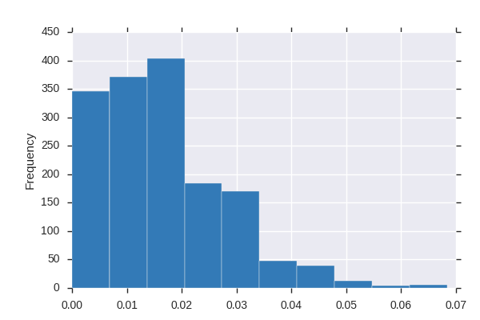

margin38  
Numeric

| Distinct count | 59 |
| --- | --- |
| Unique (%) | 3.7% |
| Missing (%) | 0.0% |
| Missing (n) | 0 |
| Infinite (%) | 0.0% |
| Infinite (n) | 0 |

| Mean | 0.030947 |
| --- | --- |
| Minimum | 0 |
| Maximum | 0.14063 |
| Zeros (%) | 5.1% |

Toggle details

Quantile statistics

| Minimum | 0 |
| --- | --- |
| 5-th percentile | 0.00029295 |
| Q1 | 0.009766 |
| Median | 0.027344 |
| Q3 | 0.046875 |
| 95-th percentile | 0.072266 |
| Maximum | 0.14063 |
| Range | 0.14063 |
| Interquartile range | 0.037109 |

Descriptive statistics

| Standard deviation | 0.023154 |
| --- | --- |
| Coef of variation | 0.7482 |
| Kurtosis | 0.24501 |
| Mean | 0.030947 |
| MAD | 0.019226 |
| Skewness | 0.70749 |
| Sum | 49.02 |
| Variance | 0.00053613 |
| Memory size | 12.5 KiB |

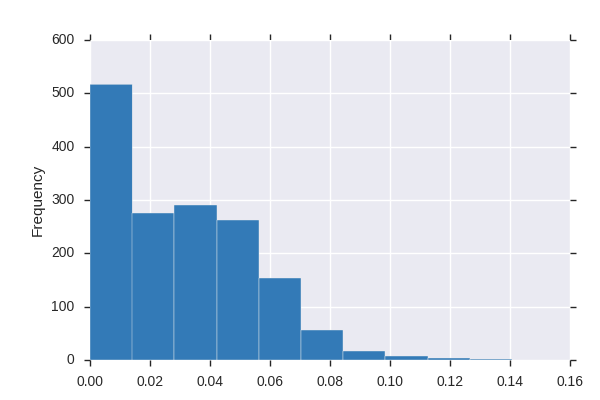

margin39  
Numeric

| Distinct count | 32 |
| --- | --- |
| Unique (%) | 2.0% |
| Missing (%) | 0.0% |
| Missing (n) | 0 |
| Infinite (%) | 0.0% |
| Infinite (n) | 0 |

| Mean | 0.014976 |
| --- | --- |
| Minimum | 0 |
| Maximum | 0.066406 |
| Zeros (%) | 12.4% |

Toggle details

Quantile statistics

| Minimum | 0 |
| --- | --- |
| 5-th percentile | 0 |
| Q1 | 0.003906 |
| Median | 0.011719 |
| Q3 | 0.023438 |
| 95-th percentile | 0.041016 |
| Maximum | 0.066406 |
| Range | 0.066406 |
| Interquartile range | 0.019532 |

Descriptive statistics

| Standard deviation | 0.013368 |
| --- | --- |
| Coef of variation | 0.89263 |
| Kurtosis | 0.16924 |
| Mean | 0.014976 |
| MAD | 0.01093 |
| Skewness | 0.89614 |
| Sum | 23.723 |
| Variance | 0.00017871 |
| Memory size | 12.5 KiB |

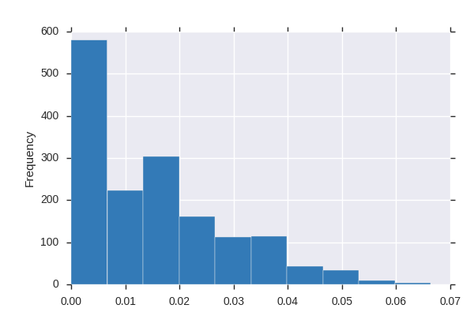

margin4  
Numeric

| Distinct count | 78 |
| --- | --- |
| Unique (%) | 4.9% |
| Missing (%) | 0.0% |
| Missing (n) | 0 |
| Infinite (%) | 0.0% |
| Infinite (n) | 0 |

| Mean | 0.023008 |
| --- | --- |
| Minimum | 0 |
| Maximum | 0.16992 |
| Zeros (%) | 7.2% |

Toggle details

Quantile statistics

| Minimum | 0 |
| --- | --- |
| 5-th percentile | 0 |
| Q1 | 0.005859 |
| Median | 0.013672 |
| Q3 | 0.029297 |
| 95-th percentile | 0.083984 |
| Maximum | 0.16992 |
| Range | 0.16992 |
| Interquartile range | 0.023438 |

Descriptive statistics

| Standard deviation | 0.02855 |
| --- | --- |
| Coef of variation | 1.2408 |
| Kurtosis | 6.9961 |
| Mean | 0.023008 |
| MAD | 0.019199 |
| Skewness | 2.4888 |
| Sum | 36.445 |
| Variance | 0.00081507 |
| Memory size | 12.5 KiB |

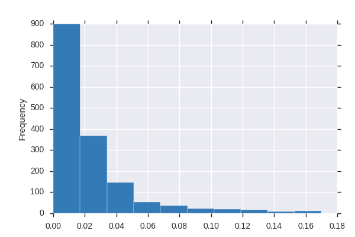

margin40  
Numeric

| Distinct count | 34 |
| --- | --- |
| Unique (%) | 2.1% |
| Missing (%) | 0.0% |
| Missing (n) | 0 |
| Infinite (%) | 0.0% |
| Infinite (n) | 0 |

| Mean | 0.0082403 |
| --- | --- |
| Minimum | 0 |
| Maximum | 0.072266 |
| Zeros (%) | 29.5% |

Toggle details

Quantile statistics

| Minimum | 0 |
| --- | --- |
| 5-th percentile | 0 |
| Q1 | 0 |
| Median | 0.003906 |
| Q3 | 0.011719 |
| 95-th percentile | 0.029297 |
| Maximum | 0.072266 |
| Range | 0.072266 |
| Interquartile range | 0.011719 |

Descriptive statistics

| Standard deviation | 0.010636 |
| --- | --- |
| Coef of variation | 1.2907 |
| Kurtosis | 4.2786 |
| Mean | 0.0082403 |
| MAD | 0.008007 |
| Skewness | 1.8907 |
| Sum | 13.053 |
| Variance | 0.00011312 |
| Memory size | 12.5 KiB |

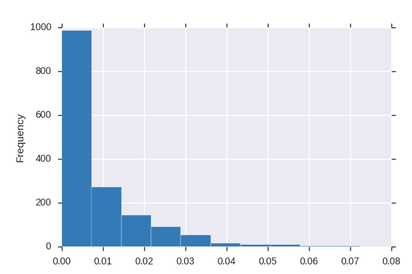

margin41  
Numeric

| Distinct count | 66 |
| --- | --- |
| Unique (%) | 4.2% |
| Missing (%) | 0.0% |
| Missing (n) | 0 |
| Infinite (%) | 0.0% |
| Infinite (n) | 0 |

| Mean | 0.010643 |
| --- | --- |
| Minimum | 0 |
| Maximum | 0.20898 |
| Zeros (%) | 43.2% |

Toggle details

Quantile statistics

| Minimum | 0 |
| --- | --- |
| 5-th percentile | 0 |
| Q1 | 0 |
| Median | 0.001953 |
| Q3 | 0.009766 |
| 95-th percentile | 0.048828 |
| Maximum | 0.20898 |
| Range | 0.20898 |
| Interquartile range | 0.009766 |

Descriptive statistics

| Standard deviation | 0.022965 |
| --- | --- |
| Coef of variation | 2.1577 |
| Kurtosis | 25.933 |
| Mean | 0.010643 |
| MAD | 0.01319 |
| Skewness | 4.4517 |
| Sum | 16.859 |
| Variance | 0.00052739 |
| Memory size | 12.5 KiB |

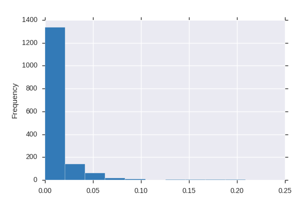

margin42  
Numeric

| Distinct count | 42 |
| --- | --- |
| Unique (%) | 2.7% |
| Missing (%) | 0.0% |
| Missing (n) | 0 |
| Infinite (%) | 0.0% |
| Infinite (n) | 0 |

| Mean | 0.017656 |
| --- | --- |
| Minimum | 0 |
| Maximum | 0.091797 |
| Zeros (%) | 6.5% |

Toggle details

Quantile statistics

| Minimum | 0 |
| --- | --- |
| 5-th percentile | 0 |
| Q1 | 0.005859 |
| Median | 0.013672 |
| Q3 | 0.025391 |
| 95-th percentile | 0.044922 |
| Maximum | 0.091797 |
| Range | 0.091797 |
| Interquartile range | 0.019532 |

Descriptive statistics

| Standard deviation | 0.0147 |
| --- | --- |
| Coef of variation | 0.8326 |
| Kurtosis | 1.8474 |
| Mean | 0.017656 |
| MAD | 0.011549 |
| Skewness | 1.208 |
| Sum | 27.967 |
| Variance | 0.00021609 |
| Memory size | 12.5 KiB |

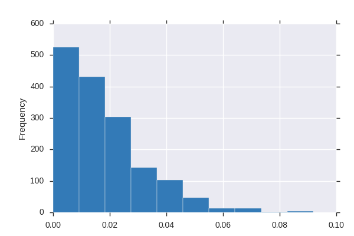

margin43  
Numeric

| Distinct count | 54 |
| --- | --- |
| Unique (%) | 3.4% |
| Missing (%) | 0.0% |
| Missing (n) | 0 |
| Infinite (%) | 0.0% |
| Infinite (n) | 0 |

| Mean | 0.018765 |
| --- | --- |
| Minimum | 0 |
| Maximum | 0.11719 |
| Zeros (%) | 15.0% |

Toggle details

Quantile statistics

| Minimum | 0 |
| --- | --- |
| 5-th percentile | 0 |
| Q1 | 0.003906 |
| Median | 0.009766 |
| Q3 | 0.027344 |
| 95-th percentile | 0.064453 |
| Maximum | 0.11719 |
| Range | 0.11719 |
| Interquartile range | 0.023438 |

Descriptive statistics

| Standard deviation | 0.02104 |
| --- | --- |
| Coef of variation | 1.1212 |
| Kurtosis | 2.5813 |
| Mean | 0.018765 |
| MAD | 0.015986 |
| Skewness | 1.6536 |
| Sum | 29.725 |
| Variance | 0.00044269 |
| Memory size | 12.5 KiB |

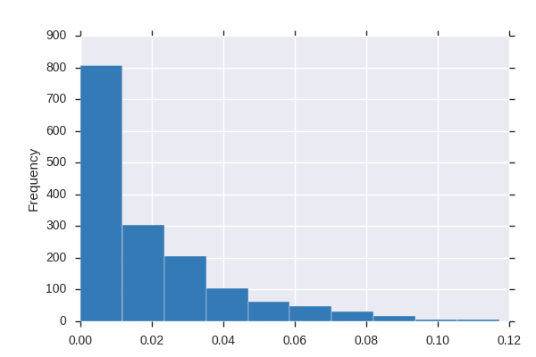

margin44  
Numeric

| Distinct count | 32 |
| --- | --- |
| Unique (%) | 2.0% |
| Missing (%) | 0.0% |
| Missing (n) | 0 |
| Infinite (%) | 0.0% |
| Infinite (n) | 0 |

| Mean | 0.012588 |
| --- | --- |
| Minimum | 0 |
| Maximum | 0.064453 |
| Zeros (%) | 9.3% |

Toggle details

Quantile statistics

| Minimum | 0 |
| --- | --- |
| 5-th percentile | 0 |
| Q1 | 0.003906 |
| Median | 0.009766 |
| Q3 | 0.017578 |
| 95-th percentile | 0.035156 |
| Maximum | 0.064453 |
| Range | 0.064453 |
| Interquartile range | 0.013672 |

Descriptive statistics

| Standard deviation | 0.011593 |
| --- | --- |
| Coef of variation | 0.92099 |
| Kurtosis | 1.6473 |
| Mean | 0.012588 |
| MAD | 0.0090951 |
| Skewness | 1.3256 |
| Sum | 19.939 |
| Variance | 0.00013441 |
| Memory size | 12.5 KiB |

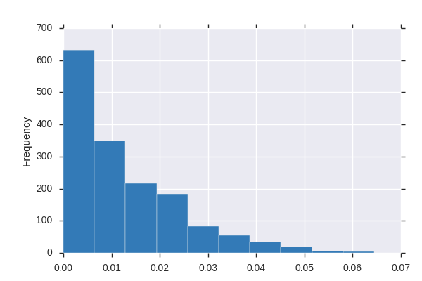

margin45  
Numeric

| Distinct count | 67 |
| --- | --- |
| Unique (%) | 4.2% |
| Missing (%) | 0.0% |
| Missing (n) | 0 |
| Infinite (%) | 0.0% |
| Infinite (n) | 0 |

| Mean | 0.024781 |
| --- | --- |
| Minimum | 0 |
| Maximum | 0.17773 |
| Zeros (%) | 5.6% |

Toggle details

Quantile statistics

| Minimum | 0 |
| --- | --- |
| 5-th percentile | 0 |
| Q1 | 0.005859 |
| Median | 0.017578 |
| Q3 | 0.035156 |
| 95-th percentile | 0.075879 |
| Maximum | 0.17773 |
| Range | 0.17773 |
| Interquartile range | 0.029297 |

Descriptive statistics

| Standard deviation | 0.024478 |
| --- | --- |
| Coef of variation | 0.98774 |
| Kurtosis | 3.5286 |
| Mean | 0.024781 |
| MAD | 0.018497 |
| Skewness | 1.6859 |
| Sum | 39.254 |
| Variance | 0.00059915 |
| Memory size | 12.5 KiB |

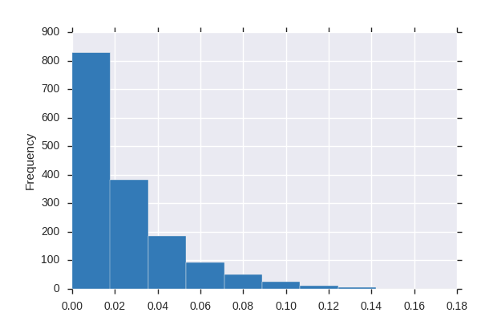

margin46  
Numeric

| Distinct count | 37 |
| --- | --- |
| Unique (%) | 2.3% |
| Missing (%) | 0.0% |
| Missing (n) | 0 |
| Infinite (%) | 0.0% |
| Infinite (n) | 0 |

| Mean | 0.010151 |
| --- | --- |
| Minimum | 0 |
| Maximum | 0.089844 |
| Zeros (%) | 26.6% |

Toggle details

Quantile statistics

| Minimum | 0 |
| --- | --- |
| 5-th percentile | 0 |
| Q1 | 0 |
| Median | 0.003906 |
| Q3 | 0.015625 |
| 95-th percentile | 0.037109 |
| Maximum | 0.089844 |
| Range | 0.089844 |
| Interquartile range | 0.015625 |

Descriptive statistics

| Standard deviation | 0.01304 |
| --- | --- |
| Coef of variation | 1.2845 |
| Kurtosis | 3.7668 |
| Mean | 0.010151 |
| MAD | 0.009933 |
| Skewness | 1.8227 |
| Sum | 16.08 |
| Variance | 0.00017004 |
| Memory size | 12.5 KiB |

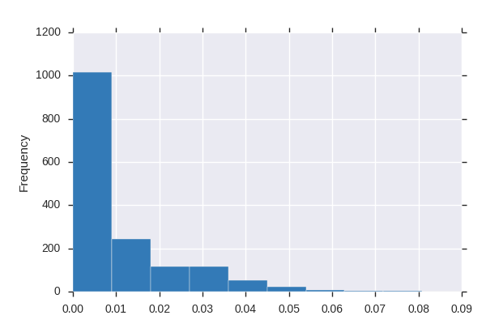

margin47  
Numeric

| Distinct count | 51 |
| --- | --- |
| Unique (%) | 3.2% |
| Missing (%) | 0.0% |
| Missing (n) | 0 |
| Infinite (%) | 0.0% |
| Infinite (n) | 0 |

| Mean | 0.025553 |
| --- | --- |
| Minimum | 0 |
| Maximum | 0.10547 |
| Zeros (%) | 11.4% |

Toggle details

Quantile statistics

| Minimum | 0 |
| --- | --- |
| 5-th percentile | 0 |
| Q1 | 0.005859 |
| Median | 0.021484 |
| Q3 | 0.041016 |
| 95-th percentile | 0.0625 |
| Maximum | 0.10547 |
| Range | 0.10547 |
| Interquartile range | 0.035157 |

Descriptive statistics

| Standard deviation | 0.021479 |
| --- | --- |
| Coef of variation | 0.84054 |
| Kurtosis | -0.19322 |
| Mean | 0.025553 |
| MAD | 0.018184 |
| Skewness | 0.68096 |
| Sum | 40.476 |
| Variance | 0.00046133 |
| Memory size | 12.5 KiB |

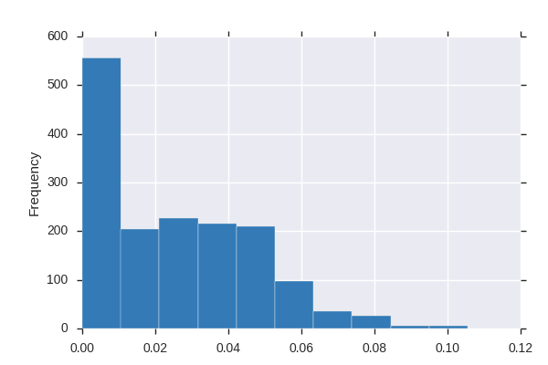

margin48  
Numeric

| Distinct count | 77 |
| --- | --- |
| Unique (%) | 4.9% |
| Missing (%) | 0.0% |
| Missing (n) | 0 |
| Infinite (%) | 0.0% |
| Infinite (n) | 0 |

| Mean | 0.027196 |
| --- | --- |
| Minimum | 0 |
| Maximum | 0.18359 |
| Zeros (%) | 19.1% |

Toggle details

Quantile statistics

| Minimum | 0 |
| --- | --- |
| 5-th percentile | 0 |
| Q1 | 0.001953 |
| Median | 0.017578 |
| Q3 | 0.044922 |
| 95-th percentile | 0.083984 |
| Maximum | 0.18359 |
| Range | 0.18359 |
| Interquartile range | 0.042969 |

Descriptive statistics

| Standard deviation | 0.030178 |
| --- | --- |
| Coef of variation | 1.1097 |
| Kurtosis | 2.0961 |
| Mean | 0.027196 |
| MAD | 0.024228 |
| Skewness | 1.4014 |
| Sum | 43.078 |
| Variance | 0.00091072 |
| Memory size | 12.5 KiB |

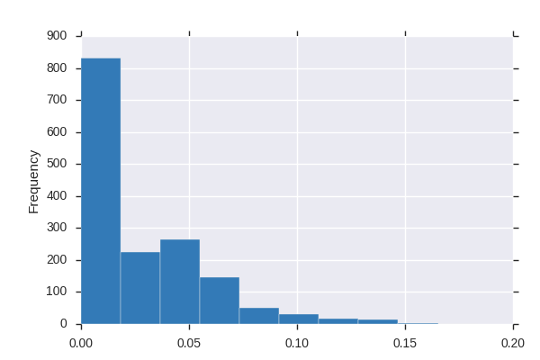

margin49  
Numeric

| Distinct count | 49 |
| --- | --- |
| Unique (%) | 3.1% |
| Missing (%) | 0.0% |
| Missing (n) | 0 |
| Infinite (%) | 0.0% |
| Infinite (n) | 0 |

| Mean | 0.008609 |
| --- | --- |
| Minimum | 0 |
| Maximum | 0.10742 |
| Zeros (%) | 47.5% |

Toggle details

Quantile statistics

| Minimum | 0 |
| --- | --- |
| 5-th percentile | 0 |
| Q1 | 0 |
| Median | 0.001953 |
| Q3 | 0.009766 |
| 95-th percentile | 0.044922 |
| Maximum | 0.10742 |
| Range | 0.10742 |
| Interquartile range | 0.009766 |

Descriptive statistics

| Standard deviation | 0.016008 |
| --- | --- |
| Coef of variation | 1.8594 |
| Kurtosis | 7.4857 |
| Mean | 0.008609 |
| MAD | 0.010775 |
| Skewness | 2.6398 |
| Sum | 13.637 |
| Variance | 0.00025625 |
| Memory size | 12.5 KiB |

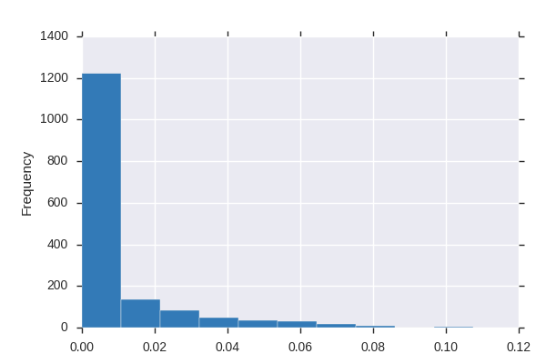

margin5  
Numeric

| Distinct count | 53 |
| --- | --- |
| Unique (%) | 3.3% |
| Missing (%) | 0.0% |
| Missing (n) | 0 |
| Infinite (%) | 0.0% |
| Infinite (n) | 0 |

| Mean | 0.014362 |
| --- | --- |
| Minimum | 0 |
| Maximum | 0.11133 |
| Zeros (%) | 19.9% |

Toggle details

Quantile statistics

| Minimum | 0 |
| --- | --- |
| 5-th percentile | 0 |
| Q1 | 0.001953 |
| Median | 0.007812 |
| Q3 | 0.019531 |
| 95-th percentile | 0.054688 |
| Maximum | 0.11133 |
| Range | 0.11133 |
| Interquartile range | 0.017578 |

Descriptive statistics

| Standard deviation | 0.01825 |
| --- | --- |
| Coef of variation | 1.2707 |
| Kurtosis | 4.5477 |
| Mean | 0.014362 |
| MAD | 0.013194 |
| Skewness | 2.0438 |
| Sum | 22.75 |
| Variance | 0.00033307 |
| Memory size | 12.5 KiB |

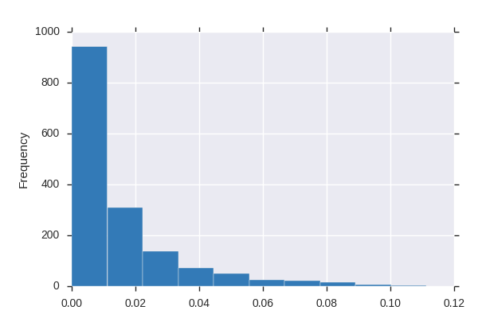

margin50  
Numeric

| Distinct count | 43 |
| --- | --- |
| Unique (%) | 2.7% |
| Missing (%) | 0.0% |
| Missing (n) | 0 |
| Infinite (%) | 0.0% |
| Infinite (n) | 0 |

| Mean | 0.013742 |
| --- | --- |
| Minimum | 0 |
| Maximum | 0.091797 |
| Zeros (%) | 30.7% |

Toggle details

Quantile statistics

| Minimum | 0 |
| --- | --- |
| 5-th percentile | 0 |
| Q1 | 0 |
| Median | 0.005859 |
| Q3 | 0.021484 |
| 95-th percentile | 0.050781 |
| Maximum | 0.091797 |
| Range | 0.091797 |
| Interquartile range | 0.021484 |

Descriptive statistics

| Standard deviation | 0.017317 |
| --- | --- |
| Coef of variation | 1.2601 |
| Kurtosis | 1.6914 |
| Mean | 0.013742 |
| MAD | 0.013611 |
| Skewness | 1.4983 |
| Sum | 21.767 |
| Variance | 0.00029987 |
| Memory size | 12.5 KiB |

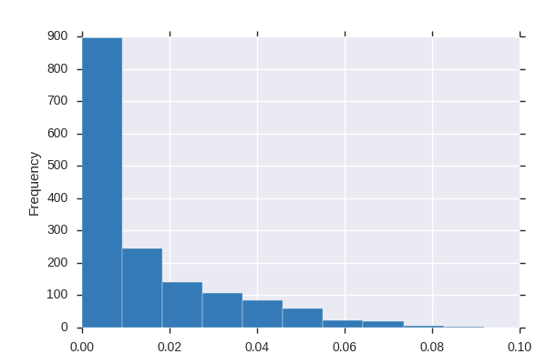

margin51  
Numeric

| Distinct count | 62 |
| --- | --- |
| Unique (%) | 3.9% |
| Missing (%) | 0.0% |
| Missing (n) | 0 |
| Infinite (%) | 0.0% |
| Infinite (n) | 0 |

| Mean | 0.025642 |
| --- | --- |
| Minimum | 0 |
| Maximum | 0.13086 |
| Zeros (%) | 11.9% |

Toggle details

Quantile statistics

| Minimum | 0 |
| --- | --- |
| 5-th percentile | 0 |
| Q1 | 0.005859 |
| Median | 0.019531 |
| Q3 | 0.039062 |
| 95-th percentile | 0.076172 |
| Maximum | 0.13086 |
| Range | 0.13086 |
| Interquartile range | 0.033203 |

Descriptive statistics

| Standard deviation | 0.024634 |
| --- | --- |
| Coef of variation | 0.9607 |
| Kurtosis | 0.92346 |
| Mean | 0.025642 |
| MAD | 0.019763 |
| Skewness | 1.1454 |
| Sum | 40.617 |
| Variance | 0.00060685 |
| Memory size | 12.5 KiB |

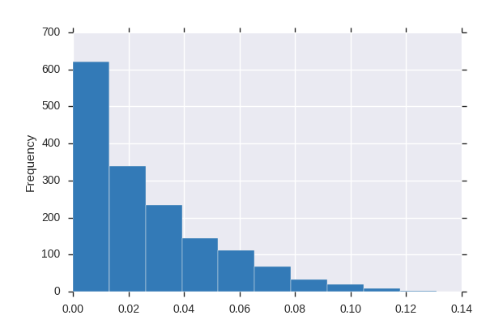

margin52  
Numeric

| Distinct count | 29 |
| --- | --- |
| Unique (%) | 1.8% |
| Missing (%) | 0.0% |
| Missing (n) | 0 |
| Infinite (%) | 0.0% |
| Infinite (n) | 0 |

| Mean | 0.0026756 |
| --- | --- |
| Minimum | 0 |
| Maximum | 0.083984 |
| Zeros (%) | 64.1% |

Toggle details

Quantile statistics

| Minimum | 0 |
| --- | --- |
| 5-th percentile | 0 |
| Q1 | 0 |
| Median | 0 |
| Q3 | 0.001953 |
| 95-th percentile | 0.013672 |
| Maximum | 0.083984 |
| Range | 0.083984 |
| Interquartile range | 0.001953 |

Descriptive statistics

| Standard deviation | 0.0073787 |
| --- | --- |
| Coef of variation | 2.7577 |
| Kurtosis | 43.574 |
| Mean | 0.0026756 |
| MAD | 0.0036534 |
| Skewness | 5.7803 |
| Sum | 4.2382 |
| Variance | 5.4445e-05 |
| Memory size | 12.5 KiB |

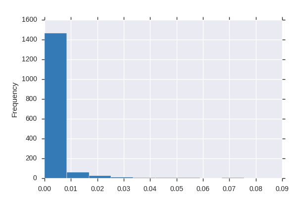

margin53  
Numeric

| Distinct count | 45 |
| --- | --- |
| Unique (%) | 2.8% |
| Missing (%) | 0.0% |
| Missing (n) | 0 |
| Infinite (%) | 0.0% |
| Infinite (n) | 0 |

| Mean | 0.024114 |
| --- | --- |
| Minimum | 0 |
| Maximum | 0.097656 |
| Zeros (%) | 5.3% |

Toggle details

Quantile statistics

| Minimum | 0 |
| --- | --- |
| 5-th percentile | 0 |
| Q1 | 0.009766 |
| Median | 0.021484 |
| Q3 | 0.035156 |
| 95-th percentile | 0.058594 |
| Maximum | 0.097656 |
| Range | 0.097656 |
| Interquartile range | 0.02539 |

Descriptive statistics

| Standard deviation | 0.018088 |
| --- | --- |
| Coef of variation | 0.75007 |
| Kurtosis | 0.18059 |
| Mean | 0.024114 |
| MAD | 0.014689 |
| Skewness | 0.79303 |
| Sum | 38.197 |
| Variance | 0.00032716 |
| Memory size | 12.5 KiB |

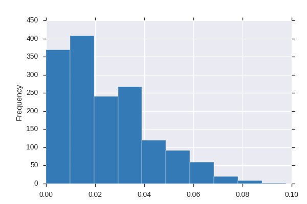

margin54  
Numeric

| Distinct count | 49 |
| --- | --- |
| Unique (%) | 3.1% |
| Missing (%) | 0.0% |
| Missing (n) | 0 |
| Infinite (%) | 0.0% |
| Infinite (n) | 0 |

| Mean | 0.010097 |
| --- | --- |
| Minimum | 0 |
| Maximum | 0.12891 |
| Zeros (%) | 35.0% |

Toggle details

Quantile statistics

| Minimum | 0 |
| --- | --- |
| 5-th percentile | 0 |
| Q1 | 0 |
| Median | 0.003906 |
| Q3 | 0.013672 |
| 95-th percentile | 0.041016 |
| Maximum | 0.12891 |
| Range | 0.12891 |
| Interquartile range | 0.013672 |

Descriptive statistics

| Standard deviation | 0.015533 |
| --- | --- |
| Coef of variation | 1.5383 |
| Kurtosis | 9.1641 |
| Mean | 0.010097 |
| MAD | 0.011217 |
| Skewness | 2.5389 |
| Sum | 15.994 |
| Variance | 0.00024127 |
| Memory size | 12.5 KiB |

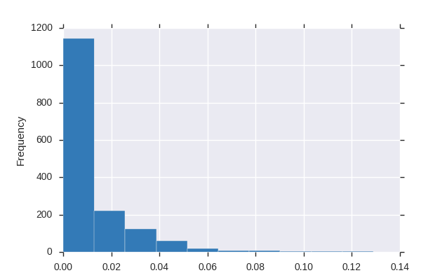

margin55  
Numeric

| Distinct count | 59 |
| --- | --- |
| Unique (%) | 3.7% |
| Missing (%) | 0.0% |
| Missing (n) | 0 |
| Infinite (%) | 0.0% |
| Infinite (n) | 0 |

| Mean | 0.018012 |
| --- | --- |
| Minimum | 0 |
| Maximum | 0.14063 |
| Zeros (%) | 23.7% |

Toggle details

Quantile statistics

| Minimum | 0 |
| --- | --- |
| 5-th percentile | 0 |
| Q1 | 0.001953 |
| Median | 0.011719 |
| Q3 | 0.027344 |
| 95-th percentile | 0.064453 |
| Maximum | 0.14063 |
| Range | 0.14063 |
| Interquartile range | 0.025391 |

Descriptive statistics

| Standard deviation | 0.021669 |
| --- | --- |
| Coef of variation | 1.203 |
| Kurtosis | 3.9071 |
| Mean | 0.018012 |
| MAD | 0.016103 |
| Skewness | 1.8394 |
| Sum | 28.531 |
| Variance | 0.00046952 |
| Memory size | 12.5 KiB |

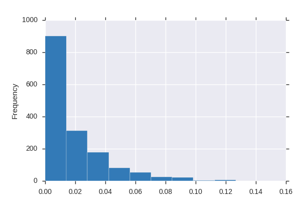

margin56  
Numeric

| Distinct count | 25 |
| --- | --- |
| Unique (%) | 1.6% |
| Missing (%) | 0.0% |
| Missing (n) | 0 |
| Infinite (%) | 0.0% |
| Infinite (n) | 0 |

| Mean | 0.006048 |
| --- | --- |
| Minimum | 0 |
| Maximum | 0.054688 |
| Zeros (%) | 41.4% |

Toggle details

Quantile statistics

| Minimum | 0 |
| --- | --- |
| 5-th percentile | 0 |
| Q1 | 0 |
| Median | 0.001953 |
| Q3 | 0.007812 |
| 95-th percentile | 0.025391 |
| Maximum | 0.054688 |
| Range | 0.054688 |
| Interquartile range | 0.007812 |

Descriptive statistics

| Standard deviation | 0.0089739 |
| --- | --- |
| Coef of variation | 1.4838 |
| Kurtosis | 3.378 |
| Mean | 0.006048 |
| MAD | 0.0066735 |
| Skewness | 1.9035 |
| Sum | 9.58 |
| Variance | 8.0531e-05 |
| Memory size | 12.5 KiB |

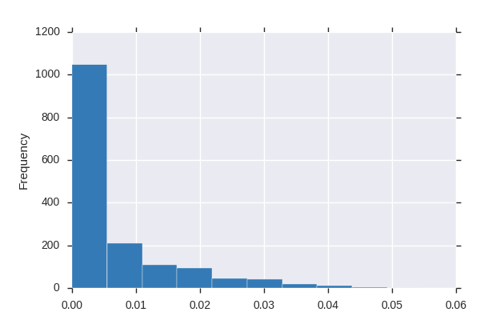

margin57  
Numeric

| Distinct count | 30 |
| --- | --- |
| Unique (%) | 1.9% |
| Missing (%) | 0.0% |
| Missing (n) | 0 |
| Infinite (%) | 0.0% |
| Infinite (n) | 0 |

| Mean | 0.012378 |
| --- | --- |
| Minimum | 0 |
| Maximum | 0.0625 |
| Zeros (%) | 5.5% |

Toggle details

Quantile statistics

| Minimum | 0 |
| --- | --- |
| 5-th percentile | 0 |
| Q1 | 0.005859 |
| Median | 0.009766 |
| Q3 | 0.017578 |
| 95-th percentile | 0.03125 |
| Maximum | 0.0625 |
| Range | 0.0625 |
| Interquartile range | 0.011719 |

Descriptive statistics

| Standard deviation | 0.0097439 |
| --- | --- |
| Coef of variation | 0.78717 |
| Kurtosis | 2.4973 |
| Mean | 0.012378 |
| MAD | 0.0074309 |
| Skewness | 1.3753 |
| Sum | 19.607 |
| Variance | 9.4943e-05 |
| Memory size | 12.5 KiB |

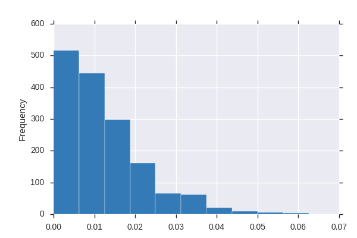

margin58  
Numeric

| Distinct count | 53 |
| --- | --- |
| Unique (%) | 3.3% |
| Missing (%) | 0.0% |
| Missing (n) | 0 |
| Infinite (%) | 0.0% |
| Infinite (n) | 0 |

| Mean | 0.020253 |
| --- | --- |
| Minimum | 0 |
| Maximum | 0.11328 |
| Zeros (%) | 7.8% |

Toggle details

Quantile statistics

| Minimum | 0 |
| --- | --- |
| 5-th percentile | 0 |
| Q1 | 0.005859 |
| Median | 0.015625 |
| Q3 | 0.029297 |
| 95-th percentile | 0.058594 |
| Maximum | 0.11328 |
| Range | 0.11328 |
| Interquartile range | 0.023438 |

Descriptive statistics

| Standard deviation | 0.0188 |
| --- | --- |
| Coef of variation | 0.92828 |
| Kurtosis | 2.5027 |
| Mean | 0.020253 |
| MAD | 0.014471 |
| Skewness | 1.4408 |
| Sum | 32.08 |
| Variance | 0.00035344 |
| Memory size | 12.5 KiB |

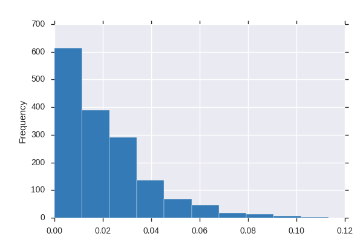

margin59  
Numeric

| Distinct count | 93 |
| --- | --- |
| Unique (%) | 5.9% |
| Missing (%) | 0.0% |
| Missing (n) | 0 |
| Infinite (%) | 0.0% |
| Infinite (n) | 0 |

| Mean | 0.031037 |
| --- | --- |
| Minimum | 0 |
| Maximum | 0.25195 |
| Zeros (%) | 2.0% |

Toggle details

Quantile statistics

| Minimum | 0 |
| --- | --- |
| 5-th percentile | 0.001953 |
| Q1 | 0.011719 |
| Median | 0.022461 |
| Q3 | 0.039062 |
| 95-th percentile | 0.09707 |
| Maximum | 0.25195 |
| Range | 0.25195 |
| Interquartile range | 0.027343 |

Descriptive statistics

| Standard deviation | 0.03264 |
| --- | --- |
| Coef of variation | 1.0517 |
| Kurtosis | 10.101 |
| Mean | 0.031037 |
| MAD | 0.020985 |
| Skewness | 2.8095 |
| Sum | 49.162 |
| Variance | 0.0010654 |
| Memory size | 12.5 KiB |

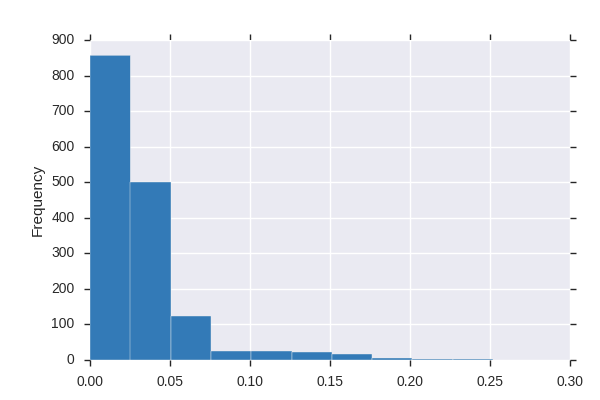

margin6  
Numeric

| Distinct count | 121 |
| --- | --- |
| Unique (%) | 7.6% |
| Missing (%) | 0.0% |
| Missing (n) | 0 |
| Infinite (%) | 0.0% |
| Infinite (n) | 0 |

| Mean | 0.038174 |
| --- | --- |
| Minimum | 0 |
| Maximum | 0.31055 |
| Zeros (%) | 26.9% |

Toggle details

Quantile statistics

| Minimum | 0 |
| --- | --- |
| 5-th percentile | 0 |
| Q1 | 0 |
| Median | 0.013672 |
| Q3 | 0.056641 |
| 95-th percentile | 0.14648 |
| Maximum | 0.31055 |
| Range | 0.31055 |
| Interquartile range | 0.056641 |

Descriptive statistics

| Standard deviation | 0.051771 |
| --- | --- |
| Coef of variation | 1.3562 |
| Kurtosis | 3.0538 |
| Mean | 0.038174 |
| MAD | 0.03971 |
| Skewness | 1.7676 |
| Sum | 60.467 |
| Variance | 0.0026802 |
| Memory size | 12.5 KiB |

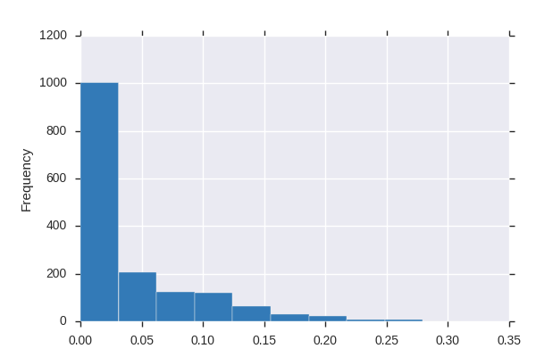

margin60  
Numeric

| Distinct count | 40 |
| --- | --- |
| Unique (%) | 2.5% |
| Missing (%) | 0.0% |
| Missing (n) | 0 |
| Infinite (%) | 0.0% |
| Infinite (n) | 0 |

| Mean | 0.011925 |
| --- | --- |
| Minimum | 0 |
| Maximum | 0.089844 |
| Zeros (%) | 12.2% |

Toggle details

Quantile statistics

| Minimum | 0 |
| --- | --- |
| 5-th percentile | 0 |
| Q1 | 0.003906 |
| Median | 0.007812 |
| Q3 | 0.015625 |
| 95-th percentile | 0.035156 |
| Maximum | 0.089844 |
| Range | 0.089844 |
| Interquartile range | 0.011719 |

Descriptive statistics

| Standard deviation | 0.012352 |
| --- | --- |
| Coef of variation | 1.0358 |
| Kurtosis | 7.4834 |
| Mean | 0.011925 |
| MAD | 0.0087958 |
| Skewness | 2.2276 |
| Sum | 18.889 |
| Variance | 0.00015256 |
| Memory size | 12.5 KiB |

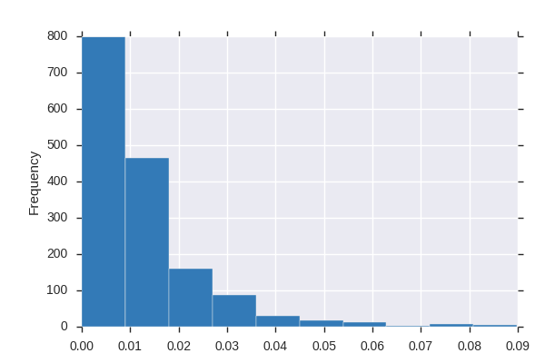

margin61  
Numeric

| Distinct count | 10 |
| --- | --- |
| Unique (%) | 0.6% |
| Missing (%) | 0.0% |
| Missing (n) | 0 |
| Infinite (%) | 0.0% |
| Infinite (n) | 0 |

| Mean | 0.0013772 |
| --- | --- |
| Minimum | 0 |
| Maximum | 0.042969 |
| Zeros (%) | 62.5% |

Toggle details

Quantile statistics

| Minimum | 0 |
| --- | --- |
| 5-th percentile | 0 |
| Q1 | 0 |
| Median | 0 |
| Q3 | 0.001953 |
| 95-th percentile | 0.007812 |
| Maximum | 0.042969 |
| Range | 0.042969 |
| Interquartile range | 0.001953 |

Descriptive statistics

| Standard deviation | 0.0025007 |
| --- | --- |
| Coef of variation | 1.8158 |
| Kurtosis | 51.097 |
| Mean | 0.0013772 |
| MAD | 0.0017215 |
| Skewness | 4.4667 |
| Sum | 2.1815 |
| Variance | 6.2536e-06 |
| Memory size | 12.5 KiB |

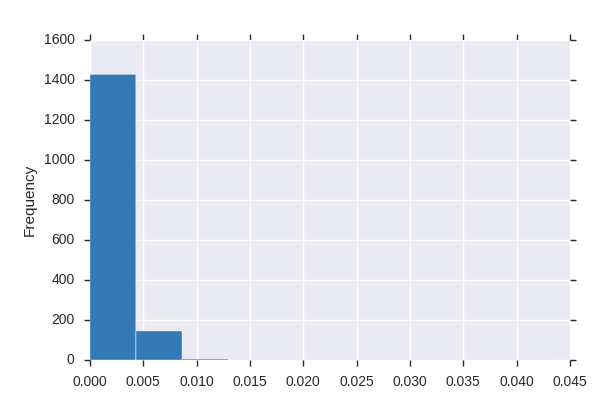

margin62  
Numeric

| Distinct count | 35 |
| --- | --- |
| Unique (%) | 2.2% |
| Missing (%) | 0.0% |
| Missing (n) | 0 |
| Infinite (%) | 0.0% |
| Infinite (n) | 0 |

| Mean | 0.0050011 |
| --- | --- |
| Minimum | 0 |
| Maximum | 0.076172 |
| Zeros (%) | 54.5% |

Toggle details